Code is hidden by default for review.

# EPL 2015/16 Foul-Win Probability Modeling

- Author: Ryan Inghilterra
- Notebook run on python 3.11 (venv)
- full notebook runs end-to-end on macbook pro laptop in less than 15 minutes

## Notebook Outline (Table of Contents)

- **Read in Data**
- **Initial Data Investigation and Analysis**
- **Model Framing and Assumptions**
- **Possession Event Extraction and Labeling**
- **Time-based Train/Test Split**
- **More EDA - Visualizing Spatial Grid-Based Foul Win Rates**
- **Feature Engineering - FX**
- **ML Model - Xgb Training and Hyperparameter Tuning with Cross-Validation**
- **ML Model Evaluation**
- **Final Results Interpretation and Analysis**

setup all package imports

- matplotlib==3.10.1
- numpy==2.2.5
- pandas==2.2.3
- shap==0.47.2
- ipython==9.2.0
- scikit-learn==1.6.1
- xgboost==3.0.0

```python
import math
from collections import Counter
from datetime import timedelta
from typing import Any, Dict, Optional

import matplotlib.patches as mpatches
import matplotlib.pyplot as plt
import numpy as np
import pandas as pd
import shap
from IPython.display import Video
from sklearn.calibration import CalibratedClassifierCV, calibration_curve
from sklearn.metrics import brier_score_loss, log_loss, roc_auc_score
from sklearn.model_selection import GridSearchCV, TimeSeriesSplit, train_test_split
from xgboost import XGBClassifier

pd.set_option("display.max_columns", 2000)
pd.set_option("display.max_rows", 1000)
```

## Read in Data

Read in the two match/event data files and understand the general structure and size

```python
matches_df = pd.read_csv(
    "./epl_2015_16_data/epl_matches_15.csv"
)
events_df = pd.read_csv(
    "./epl_2015_16_data/epl_event_data_15.csv"
)

print("Matches shape:", matches_df.shape)
print("Events shape:", events_df.shape)
```

```
Matches shape: (380, 28)
Events shape: (1313783, 49)
```

```python
matches_df.head(1)
```

|  | Unnamed: 0 | match_id | match_date | kick_off | home_score | away_score | match_status | last_updated | match_week | competition.competition_id | competition.country_name | competition.competition_name | season.season_id | season.season_name | home_team.home_team_id | home_team.home_team_name | home_team.managers | away_team.away_team_id | away_team.away_team_name | away_team.managers | competition_stage.id | competition_stage.name | stadium.id | stadium.name | referee.id | referee.name | referee.country.id | referee.country.name |
| --- | --- | --- | --- | --- | --- | --- | --- | --- | --- | --- | --- | --- | --- | --- | --- | --- | --- | --- | --- | --- | --- | --- | --- | --- | --- | --- | --- | --- |
| 0 | 1 | 3754058 | 2016-01-02 | 16:00:00.000 | 0 | 0 | available | 2021-10-29T23:44:19.940296 | 20 | 2 | England | Premier League | 27 | 2015/2016 | 22 | Leicester City | 60, Claudio Ranieri, NA, 1951-10-20, 112, Italy | 28 | AFC Bournemouth | 38, Eddie Howe, NA, 1977-11-29, 68, England | 1 | Regular Season | 20 | King Power Stadium | 5 | Andre Marriner | 68 | England |

```python
print("number of matches", matches_df.match_id.nunique())
print("number of match weeks", matches_df.match_week.nunique())
print("number of competitions", matches_df["competition.competition_id"].nunique())
print("number of home teams", matches_df["home_team.home_team_id"].nunique())
print("number of away teams", matches_df["away_team.away_team_id"].nunique())
print(sorted(matches_df["home_team.home_team_name"].unique()))
```

```
number of matches 380
number of match weeks 38
number of competitions 1
number of home teams 20
number of away teams 20
['AFC Bournemouth', 'Arsenal', 'Aston Villa', 'Chelsea', 'Crystal Palace', 'Everton', 'Leicester City', 'Liverpool', 'Manchester City', 'Manchester United', 'Newcastle United', 'Norwich City', 'Southampton', 'Stoke City', 'Sunderland', 'Swansea City', 'Tottenham Hotspur', 'Watford', 'West Bromwich A…
```

The matches dataframe makes sense, match per row, EPL only competition, 38 match weeks, 20 teams

```python
events_df.head(1)
```

|  | id | index | period | timestamp | minute | second | possession | player_possession | duration | related_events | location | under_pressure | counterpress | type.id | type.name | possession_team.id | possession_team.name | play_pattern.id | play_pattern.name | team.id | team.name | tactics.formation | tactics.lineup | player.id | player.name | position.id | position.name | pass.length | pass.angle | … |
| --- | --- | --- | --- | --- | --- | --- | --- | --- | --- | --- | --- | --- | --- | --- | --- | --- | --- | --- | --- | --- | --- | --- | --- | --- | --- | --- | --- | --- | --- | --- |
| 0 | 9153e9f4-f69c-4e04-8f64-505592e212cd | 1 | 1 | 00:00:00.000 | 0 | 0 | 1 | 1 | 0.0 | NaN | NaN | NaN | NaN | 35 | Starting XI | 22 | Leicester City | 1 | Regular Play | 22 | Leicester City | 442.0 | 1, 17, 5, 6, 28, 14, 26, 4, 11, 23, 9, 3815, 3... | NaN | NaN | NaN | NaN | NaN | NaN | … |

```python
events_df["type.name"].value_counts()
```

```
type.name
Pass                 368619
Ball Receipt*        340324
Carry                276949
Pressure             115402
Ball Recovery         40943
Duel                  32290
Clearance             21645
Block                 14839
Dribble               13721
Goal Keeper           11777
Miscontrol            10786
Dispossessed          10520
Shot                   9908
Foul Committed         9512
Foul Won               9112
Interception           8920
Dribbled Past          8771
Substitution           2109
Half Start             1520
Half End               1520
Injury Stoppage        1032
Starting XI             760
Tactical Shift          625
50/50                   559
Shield                  503
Referee Ball-Drop       272
Bad Behaviour           193
Error                   178
Player Off              145
Player On               144
Offside                 109
Own Goal For             38
Own Goal Against         38
Name: count, dtype: int64
```

each row is an event, with timestamp, match, player info, a lot of detailed fields to explore further

## Initial Data Investigation and Analysis

### Finding data specifications doc - StatsBomb

It was clear looking at the events data, that each field and column is nuanced and non-trivial to work out exactly what they represent, so spent some time seeing if I could find the data source and data specifications which give more info on the fields.

I was able to find the StatsBomb specs as a pdf here: https://github.com/statsbomb/open-data/blob/master/doc/StatsBomb%20Open%20Data%20Specification%20v1.1.pdf

which was really important to look at and had a lot of useful information on the different fields and some of the nuances of the data.

Note this may not be the exact data dictionary version aligning with this dataset but overall still very useful.

Some of the important nuances was understanding 'Ball Receipts' and 'Ball Recovery' events are not always successful, the location coordinates need to be mirrored for non-posession team players, and overall better understanding what a 'possession' represents. Also a lot of the columns (fields) have null values, which data specs shows for a lot of these columns that just means 'normal' or 'complete'.

Then it also gives a lot more insight into fields that could be potentially useful features into the model.

Note that 'player_possession' field included in the CSV but not in data spec

### Visualizing the events on the pitch - function defs

Pitch dimensions sourced from statsbomb data specification v1.1 doc: https://github.com/statsbomb/open-data/blob/master/doc/StatsBomb%20Open%20Data%20Specification%20v1.1.pdf

```python
def plot_pitch():
    """Draw a detailed soccer pitch with 6-yard boxes, penalty boxes, and center circle"""
    fig, ax = plt.subplots(figsize=(10, 6))

    # Pitch outline & center line
    ax.plot([0, 0], [0, 80], color="black")
    ax.plot([0, 120], [80, 80], color="black")
    ax.plot([120, 120], [80, 0], color="black")
    ax.plot([120, 0], [0, 0], color="black")
    ax.plot([60, 60], [0, 80], color="black")

    # Left penalty area (18-yard box)
    ax.plot([0, 18], [18, 18], color="black")
    ax.plot([18, 18], [18, 62], color="black")
    ax.plot([0, 18], [62, 62], color="black")

    # Right penalty area (18-yard box)
    ax.plot([120, 102], [18, 18], color="black")
    ax.plot([102, 102], [18, 62], color="black")
    ax.plot([102, 120], [62, 62], color="black")

    # Left 6-yard box
    ax.plot([0, 6], [30, 30], color="black")
    ax.plot([6, 6], [30, 50], color="black")
    ax.plot([0, 6], [50, 50], color="black")

    # Right 6-yard box
    ax.plot([120, 114], [30, 30], color="black")
    ax.plot([114, 114], [30, 50], color="black")
    ax.plot([120, 114], [50, 50], color="black")

    # Center circle
    center_circle = plt.Circle((60, 40), 10, color="black", fill=False)
    ax.add_patch(center_circle)

    # Setup axes
    ax.set_xlim(0, 120)
    ax.set_ylim(0, 80)
    ax.set_axis_off()
    ax.invert_yaxis()  # match (0,0) top-left convention

    return fig, ax
```

```python
def plot_actions(possess_df):
    match_id = possess_df["match_id"].iloc[0]
    possess_id = possess_df["possession"].iloc[0]

    event_color = {
        "Pass": "lightblue",
        "Ball Receipt*": "blue",
        "Ball Recovery": "darkgreen",
        "Interception": "green",
        "Carry": "purple",
        "Pressure": "red",
        "Block": "darkred",
        "Duel": "orange",
    }

    seen_coords = {}
    fig, ax = plot_pitch()

    for step, (_, row) in enumerate(possess_df.iterrows(), start=1):
        x, y = row["mirror_fix_x"], row["mirror_fix_y"]
        event = row["type.name"]
        player = row["player.name"]
        color = event_color.get(event, "gray")

        if pd.notnull(x) and pd.notnull(y):
            coord = (round(x, 1), round(y, 1))
            offset_count = seen_coords.get(coord, 0)
            jitter_x = x + 0.5 * offset_count
            jitter_y = y + 0.5 * offset_count
            seen_coords[coord] = offset_count + 1

            ax.text(
                jitter_x,
                jitter_y,
                str(step),
                fontsize=10,
                fontweight="bold",
                color=color,
                ha="center",
                va="center",
            )
            ax.text(
                jitter_x + 1,
                jitter_y + 1,
                player.split(" ")[-1],
                fontsize=8,
                color=color,
            )

    # Create custom legend
    legend_patches = [
        mpatches.Patch(color=color, label=etype) for etype, color in event_color.items()
    ]

    # Add legend to the right of the pitch
    ax.legend(
        handles=legend_patches,
        loc="center left",  # Align legend vertically center, left of anchor point
        bbox_to_anchor=(1.02, 0.5),  # Place legend just outside right of the plot
        borderaxespad=0,  # Remove internal padding
        fontsize=8,
    )
```

```
(<Figure size 1000x600 with 1 Axes>, <Axes: >)
```

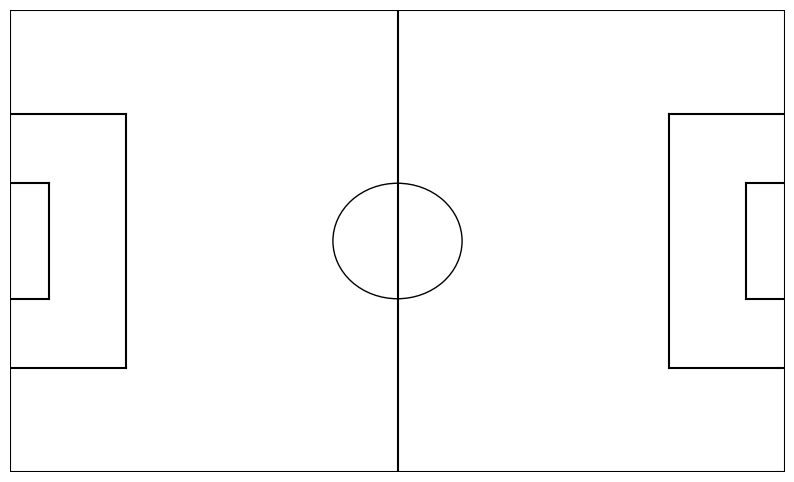

```python
plot_pitch()
```

### Deep Dive Investigate - (tottenham vs leicester) match_id: 3754065

It is useful to reduce the space of what we are looking to better understand the data and context. I have selected a single match to deep dive into some specific sequences of events to help my understanding. I am a big Tottenham supporter, and this was the season Leicester miraculously won the EPL so selected a match between them to look into. It helps that I know the team's, their players, coaches, etc.. for this season.

tottenham vs leicster, jan 13th 2016, 0-1, MW21 (note that this was the miracle season when leicester won it)

```python
test_match_id = 3754065
```

```python
# get some info on the match
matches_df[matches_df["match_id"] == test_match_id]
```

|  | Unnamed: 0 | match_id | match_date | kick_off | home_score | away_score | match_status | last_updated | match_week | competition.competition_id | competition.country_name | competition.competition_name | season.season_id | season.season_name | home_team.home_team_id | home_team.home_team_name | home_team.managers | away_team.away_team_id | away_team.away_team_name | away_team.managers | competition_stage.id | competition_stage.name | stadium.id | stadium.name | referee.id | referee.name | referee.country.id | referee.country.name |
| --- | --- | --- | --- | --- | --- | --- | --- | --- | --- | --- | --- | --- | --- | --- | --- | --- | --- | --- | --- | --- | --- | --- | --- | --- | --- | --- | --- | --- |
| 189 | 190 | 3754065 | 2016-01-13 | 21:00:00.000 | 0 | 1 | available | 2022-12-01T13:52:39.998252 | 21 | 2 | England | Premier League | 27 | 2015/2016 | 38 | Tottenham Hotspur | 81, Mauricio Roberto Pochettino Trossero, Maur... | 22 | Leicester City | 60, Claudio Ranieri, NA, 1951-10-20, 112, Italy | 1 | Regular Season | 99148 | White Hart Lane | 10 | Lee Mason | 68 | England |

```python
events_mtest_df = events_df[events_df["match_id"] == test_match_id].reset_index(
    drop=True
)
print(events_mtest_df.shape)
```

```
(3106, 49)
```

3106 total events for the match

#### Fix (mirror) x,y coordinates for non-possession team events

Note that when doing visualization we noticed the non-possession teams coordinates are not aligned on field with the possession team so we want to mirror so visualization, analysis, and overall coordinates aligned between teams within same possession

```python
# need to extract x,y coordinates for plotting
# Convert 'location' strings to x and y numeric columns
events_mtest_df["x"] = events_mtest_df["location"].apply(
    lambda s: float(s.split(",")[0].strip()) if pd.notnull(s) else None
)
events_mtest_df["y"] = events_mtest_df["location"].apply(
    lambda s: float(s.split(",")[1].strip()) if pd.notnull(s) else None
)
```

```python
# Step 1: Create the possession flag
events_mtest_df["possess_team_event"] = (
    events_mtest_df["possession_team.name"] == events_mtest_df["team.name"]
)

# Step 2: Conditionally assign mirrored or original coordinates
events_mtest_df["mirror_fix_x"] = np.where(
    events_mtest_df["possess_team_event"],
    events_mtest_df["x"],
    120 - events_mtest_df["x"],
)
events_mtest_df["mirror_fix_y"] = np.where(
    events_mtest_df["possess_team_event"],
    events_mtest_df["y"],
    80 - events_mtest_df["y"],
)
```

#### posssession 3 investigate - no foul

Lets look at a specific possession seqence of events to better understand

```python
def get_possess_df(event_m_df, possess_id):
    poss_df = event_m_df[event_m_df["possession"] == possess_id]
    return poss_df
```

```python
possess_main_cols = [
    "timestamp",
    "duration",
    "type.name",
    "possession_team.name",
    "play_pattern.name",
    "team.name",
    "player.name",
    "player_possession",
    "mirror_fix_x",
    "mirror_fix_y",
    "ball_receipt.outcome.name",
    "pass.end_location",
]
```

```python
test_possess3_df = get_possess_df(events_mtest_df, possess_id=3)
print(test_possess3_df.shape)
test_possess3_df[possess_main_cols]
```

```
(18, 54)
```

|  | timestamp | duration | type.name | possession_team.name | play_pattern.name | team.name | player.name | player_possession | mirror_fix_x | mirror_fix_y | ball_receipt.outcome.name | pass.end_location |
| --- | --- | --- | --- | --- | --- | --- | --- | --- | --- | --- | --- | --- |
| 26 | 00:00:19.142 | 0.000000 | Interception | Tottenham Hotspur | Regular Play | Tottenham Hotspur | Jan Vertonghen | 15 | 15.7 | 8.7 | NaN | NaN |
| 27 | 00:00:19.142 | 1.103334 | Carry | Tottenham Hotspur | Regular Play | Tottenham Hotspur | Jan Vertonghen | 15 | 15.7 | 8.7 | NaN | NaN |
| 28 | 00:00:19.667 | 0.843299 | Pressure | Tottenham Hotspur | Regular Play | Leicester City | Shinji Okazaki | 15 | 18.0 | 14.3 | NaN | NaN |
| 29 | 00:00:20.246 | 1.568669 | Pass | Tottenham Hotspur | Regular Play | Tottenham Hotspur | Jan Vertonghen | 15 | 15.7 | 7.6 | NaN | 38, 14.1 |
| 30 | 00:00:21.814 | NaN | Ball Receipt* | Tottenham Hotspur | Regular Play | Tottenham Hotspur | Bamidele Alli | 16 | 38.0 | 14.1 | NaN | NaN |
| 31 | 00:00:21.814 | 0.612894 | Pass | Tottenham Hotspur | Regular Play | Tottenham Hotspur | Bamidele Alli | 16 | 37.7 | 12.6 | NaN | 31.5, 13.2 |
| 32 | 00:00:22.427 | NaN | Ball Receipt* | Tottenham Hotspur | Regular Play | Tottenham Hotspur | Tom Carroll | 17 | 31.5 | 13.2 | NaN | NaN |
| 33 | 00:00:22.443 | 0.832754 | Pass | Tottenham Hotspur | Regular Play | Tottenham Hotspur | Tom Carroll | 17 | 32.6 | 13.4 | NaN | 44.5, 17.1 |
| 34 | 00:00:23.275 | NaN | Ball Receipt* | Tottenham Hotspur | Regular Play | Tottenham Hotspur | Christian Dannemann Eriksen | 18 | 44.5 | 17.1 | NaN | NaN |
| 35 | 00:00:23.275 | 0.036602 | Carry | Tottenham Hotspur | Regular Play | Tottenham Hotspur | Christian Dannemann Eriksen | 18 | 44.5 | 17.1 | NaN | NaN |
| 36 | 00:00:23.312 | 0.854946 | Pass | Tottenham Hotspur | Regular Play | Tottenham Hotspur | Christian Dannemann Eriksen | 18 | 38.5 | 26.0 | NaN | 31.1, 32 |
| 37 | 00:00:24.167 | NaN | Ball Receipt* | Tottenham Hotspur | Regular Play | Tottenham Hotspur | Eric Dier | 19 | 31.1 | 32.0 | NaN | NaN |
| 38 | 00:00:24.167 | 0.399729 | Pass | Tottenham Hotspur | Regular Play | Tottenham Hotspur | Eric Dier | 19 | 31.1 | 32.0 | NaN | 38.1, 30.1 |
| 39 | 00:00:24.567 | NaN | Ball Receipt* | Tottenham Hotspur | Regular Play | Tottenham Hotspur | Christian Dannemann Eriksen | 20 | 38.1 | 30.1 | NaN | NaN |
| 40 | 00:00:24.567 | 0.706365 | Pass | Tottenham Hotspur | Regular Play | Tottenham Hotspur | Christian Dannemann Eriksen | 20 | 38.1 | 30.1 | NaN | 54.6, 23.9 |
| 41 | 00:00:25.273 | NaN | Ball Receipt* | Tottenham Hotspur | Regular Play | Tottenham Hotspur | Bamidele Alli | 21 | 53.5 | 23.1 | Incomplete | NaN |
| 42 | 00:00:25.273 | 0.000000 | Interception | Tottenham Hotspur | Regular Play | Leicester City | Danny Simpson | 22 | 54.5 | 23.8 | NaN | NaN |
| 43 | 00:00:26.483 | 0.614010 | Pressure | Tottenham Hotspur | Regular Play | Tottenham Hotspur | Ben Davies | 22 | 41.8 | 15.1 | NaN | NaN |

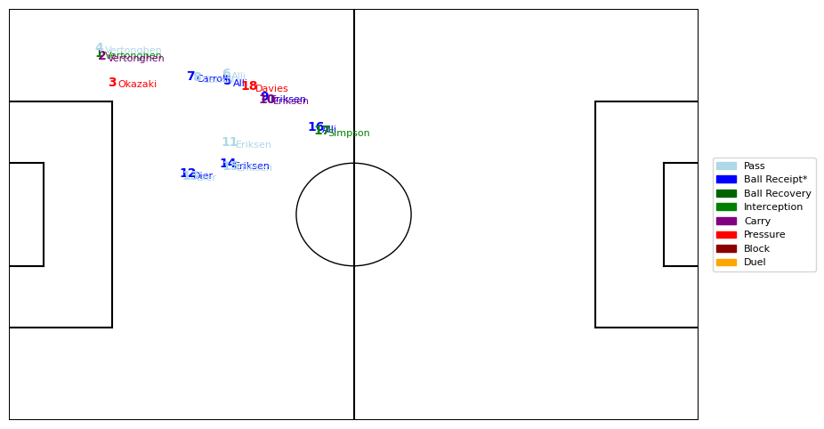

```python
plot_actions(test_possess3_df)
```

I have found a full replay of this game online and clipped the timeframe for this specific possession to help align my understanding of the events data with the real gameplay.

https://footballia.net/matches/tottenham-hotspur-leicester-city-premier-league-2015-2016

```python
Video("tott_vs_leic_poss_3.mp4", width=640, height=480)
```

[video not shown]

Its interesting events data says Eriksen had 'ball receipt' and passed to Alli near end of possession sequence but in reality Eriksen dummied it.

- I guess we can assume its fine that a dummy accounts for receiving the ball.

So in this possesion sequence, we would have the following valid 'ball receipts'

- Vertonghen - starts possession with interception which is technically a different event type to 'ball recovery'. Open question if this should be included as a valid possession to include for our model.
- Alli who has a 'ball receipt' from a successful pass from Vertoghen
- Carroll who has a 'ball receipt' from a successful pass from Alli
- Eriksen who has a 'ball receipt' from a successful pass from Carroll
- Dier who has a 'ball receipt' from a successful pass from Eriksen
- Eriksen who has a 'ball receipt' from a successful pass from Dier (though questionable b/c its a dummy through his legs)

**Note** that all of these would be 'samples' for our dataset of "players on a possession after he receives or recovers the ball". **All of these would be 'not fouled' since none ended in a 'Foul Won' event.**

Note that the ball receipt by Alli at the end of sequence is not valid player getting possession since the 'ball receipt' was 'Incomplete' for value of ball_receipt.outcome.name column.

#### posssession 48 investigate - 'foul won' example

```python
test_possess48_df = get_possess_df(events_mtest_df, possess_id=48)
print(test_possess48_df.shape)
test_possess48_df[possess_main_cols]
```

```
(8, 54)
```

|  | timestamp | duration | type.name | possession_team.name | play_pattern.name | team.name | player.name | player_possession | mirror_fix_x | mirror_fix_y | ball_receipt.outcome.name | pass.end_location |
| --- | --- | --- | --- | --- | --- | --- | --- | --- | --- | --- | --- | --- |
| 763 | 00:20:08.598 | 1.523599 | Pass | Leicester City | Regular Play | Leicester City | Danny Simpson | 346 | 63.6 | 64.7 | NaN | 66.6, 59.2 |
| 764 | 00:20:10.122 | NaN | Ball Receipt* | Leicester City | Regular Play | Leicester City | N''Golo Kanté | 347 | 66.6 | 59.2 | NaN | NaN |
| 765 | 00:20:10.122 | 1.041700 | Pass | Leicester City | Regular Play | Leicester City | N''Golo Kanté | 347 | 66.6 | 59.2 | NaN | 74.1, 68.2 |
| 766 | 00:20:10.901 | 0.726600 | Pressure | Leicester City | Regular Play | Tottenham Hotspur | Ben Davies | 347 | 80.0 | 66.8 | NaN | NaN |
| 767 | 00:20:11.163 | NaN | Ball Receipt* | Leicester City | Regular Play | Leicester City | Riyad Mahrez | 348 | 74.1 | 68.2 | NaN | NaN |
| 768 | 00:20:11.163 | 0.886997 | Carry | Leicester City | Regular Play | Leicester City | Riyad Mahrez | 348 | 74.1 | 68.2 | NaN | NaN |
| 769 | 00:20:12.050 | 0.000000 | Foul Committed | Leicester City | Regular Play | Tottenham Hotspur | Ben Davies | 348 | 77.2 | 67.6 | NaN | NaN |
| 770 | 00:20:12.050 | 0.000000 | Foul Won | Leicester City | Regular Play | Leicester City | Riyad Mahrez | 348 | 77.3 | 67.7 | NaN | NaN |

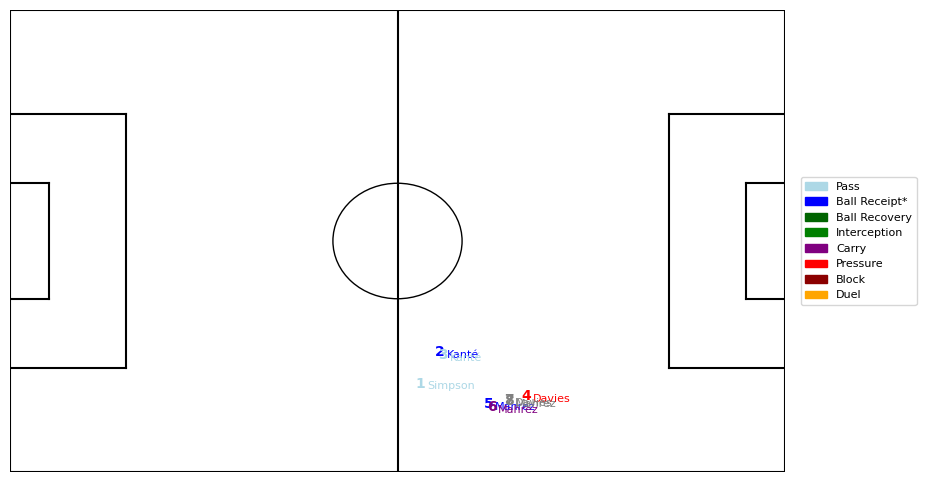

```python
plot_actions(test_possess48_df)
```

Leicester in possession, foul won by Mahrez, who is a very tricky and dangerous player, so expect him to be fouled somewhat often

```python
Video("tott_vs_leic_poss_47_48_foul.mp4", width=640, height=480)
```

[video not shown]

Watching the video, very questionable that this was marked as a successful ball receipt by Alli at end of previous possession (47). The video show he never was really in control and immediately next possession starts with Danny Simpson. something to note.

So in possesion 48 sequence, we would have the following valid 'ball receipts'

- Kante who has a complete 'ball receipt' from a pass from Simpson
- Mahrez who has a complete 'ball receipt' from a pass from Kante, and his possession continues with a carry and ends in a 'foul won'. So this would be 'fouled' since ended in a 'Foul Won' event.

Note that you could argue that the possession starting with pass event by Simpson means it could be a valid possession, but we will not count it since Simpson does not have a 'ball receipt' event associated in this sequence. Simpson directly passes first touch to Kante with his head which I guess StatsBomb does not think that is valid start of possession (Ball Receipt or Ball Recovery)

#### posssession 58 investigate - 'foul won' but not valid possession

```python
test_possess58_df = get_possess_df(events_mtest_df, possess_id=58)
print(test_possess58_df.shape)
test_possess58_df[possess_main_cols]
```

```
(15, 54)
```

|  | timestamp | duration | type.name | possession_team.name | play_pattern.name | team.name | player.name | player_possession | mirror_fix_x | mirror_fix_y | ball_receipt.outcome.name | pass.end_location |
| --- | --- | --- | --- | --- | --- | --- | --- | --- | --- | --- | --- | --- |
| 881 | 00:24:27.319 | 0.000000 | Duel | Leicester City | Regular Play | Leicester City | Shinji Okazaki | 402 | 44.3 | 18.1 | NaN | NaN |
| 882 | 00:24:28.376 | 0.000000 | Ball Recovery | Leicester City | Regular Play | Leicester City | Marc Albrighton | 403 | 43.7 | 8.3 | NaN | NaN |
| 883 | 00:24:28.376 | 2.198197 | Carry | Leicester City | Regular Play | Leicester City | Marc Albrighton | 403 | 43.7 | 8.3 | NaN | NaN |
| 884 | 00:24:29.603 | 0.606193 | Pressure | Leicester City | Regular Play | Tottenham Hotspur | Erik Lamela | 403 | 38.9 | 15.0 | NaN | NaN |
| 885 | 00:24:30.574 | 0.000000 | Dribbled Past | Leicester City | Regular Play | Tottenham Hotspur | Erik Lamela | 403 | 36.1 | 12.7 | NaN | NaN |
| 886 | 00:24:30.574 | 0.000000 | Dribble | Leicester City | Regular Play | Leicester City | Marc Albrighton | 404 | 36.2 | 12.8 | NaN | NaN |
| 887 | 00:24:30.574 | 0.733596 | Carry | Leicester City | Regular Play | Leicester City | Marc Albrighton | 404 | 36.2 | 12.8 | NaN | NaN |
| 888 | 00:24:31.308 | 1.769800 | Pass | Leicester City | Regular Play | Leicester City | Marc Albrighton | 404 | 36.2 | 12.8 | NaN | 36.6, 3.4 |
| 889 | 00:24:33.077 | NaN | Ball Receipt* | Leicester City | Regular Play | Leicester City | Christian Fuchs | 405 | 36.6 | 3.4 | NaN | NaN |
| 890 | 00:24:33.077 | 0.070099 | Carry | Leicester City | Regular Play | Leicester City | Christian Fuchs | 405 | 36.6 | 3.4 | NaN | NaN |
| 891 | 00:24:33.148 | 2.855894 | Pass | Leicester City | Regular Play | Leicester City | Christian Fuchs | 405 | 36.6 | 3.4 | NaN | 64.7, 2.1 |
| 892 | 00:24:34.867 | 1.231761 | Pressure | Leicester City | Regular Play | Tottenham Hotspur | Christian Dannemann Eriksen | 405 | 53.0 | 5.8 | NaN | NaN |
| 893 | 00:24:36.003 | NaN | Ball Receipt* | Leicester City | Regular Play | Leicester City | Danny Drinkwater | 406 | 62.3 | 3.4 | Incomplete | NaN |
| 894 | 00:24:36.340 | 0.000000 | Foul Committed | Leicester City | Regular Play | Tottenham Hotspur | Christian Dannemann Eriksen | 406 | 64.8 | 2.4 | NaN | NaN |
| 895 | 00:24:36.340 | 0.000000 | Foul Won | Leicester City | Regular Play | Leicester City | Danny Drinkwater | 406 | 64.9 | 2.5 | NaN | NaN |

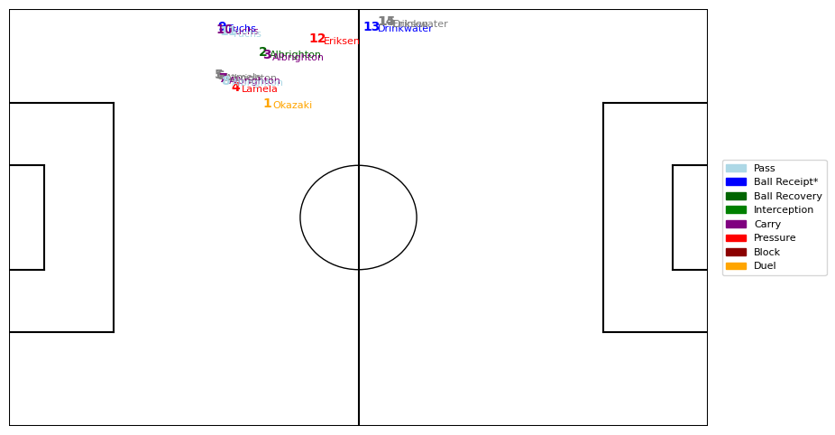

```python
plot_actions(test_possess58_df)
```

This is an interesting one, because Drinkwater won a foul but ball receipt preceding was incomplete **so not valid possession so wouldn't include this Drinkwater foul won in our corpus for our model since not valid possession from ball recovery or receipt.**

```python
Video("tott_vs_leic_poss_58.mp4", width=640, height=480)
```

[video not shown]

## Model Framing and Assumptions

"goal of predicting the probability that a player will win a foul on his possession after he receives or recovers the ball"

After looking through the data in more detail in deep dive notebook, going to make some assumptions here for how I model this.

With more time and access to stakeholders I would validate my assumptions before continuing. It is crucial to ensure we align how we frame the data and our model with stakeholder expectations.

**Input:** Valid possession start event - An event where a player gains possession (successful 'Ball Receipt*' or 'Ball Recovery')

**Output:** Probability that **the possession sequence** of a player results in the player winning a foul ('Foul Won')

**Important Note:** I only take into account possession start events at the time of player first getting possession (after receives or recovers the ball) for this project.

- One could make the argument you would potentially also want to model on not just the first instance of valid possession but if there are events such as 'carry' or 'dribble' in the sequence afterwards where player still has possession would also want to predict at those points in time. This would be something I would clarify with stakeholders but for this project assuming only looking at possession sequence start. If more time permitted, tt would be a fairly straight-forward extension of the model I built to handle those additional events within the posession additional cases.

Note on another assumption I am making, I am not including 'Interception' events as a subset of 'Ball Recovery' for these valid possessions since not explicitly stated in the initial model framing. This would be another thing I would validate with stakeholders, if we want to include 'Interceptions' or not as valid possession start events. Based on my deep dive analysis (see deep dive notebook), looking at some specific event sequences in detail and cross referecing with real video footage of the games, I think you could make the argument Interceptions could be included, but overall its relatively small % of total events anyways so should not make massive difference to include or not either way.

There are some other nuances for some corner cases which I point out in some of the following sections.

### Model Framing Outline

How to setup corpus (samples) here to model on and outcome variable as well?

Each sample will be event where player gains possession (ball receipt or ball recovery).

- Note that when looking at data specifications in more detail it is important to note that ball receipt and ball recovery events can occur unsuccessfuly, they are represent attempts, so need to only get valid ones where player gains possession. Logic to follow below.

Our target variable (label) for the sample will be binary label (True/False), whether the valid possesion event start ended with a foul won by that player or not. True if did win foul, False if not.

- Note that we would expect heavy class imbalance with very few fouls won, relative to all valid player possession start events.

## Possession Event Extraction and Labeling

Now lets build out and run our event labeling to build out our samples and labels. Note building out the features for each sample will be a separate effort later.

- Step 1: get valid possession start events
- Step 2: determine if ended in foul won or not

This is a really important step in the modeling process, to ensure we extract the data properly and build out the corpus to model on in the correct way such that we properly model on 'valid possessions' and properly label 'foul won' or not for the valid possession sequence. If the input data and samples created are not correct, all following model evaluation results may not actually align with true efficacy such that it aligns with KPIs.

### Step 1: get valid possession start events

Step 1: get valid possession start events

If successful 'Ball Receipt*', 'Ball Recovery' followed by same player ‘carry’ ‘pass’ ‘dribble’, ‘shot’, right after in sequence that is a valid possession start.

I would validate with stakeholders that the definition of valid possession start is correct but will make assumption for this project that my definition of valid possession start events is correct.

Note that we add a additional check that the following event from start possession event is within a very small amount of time. Generally that time is exactly 0 seconds, but I saw some corner cases where the 'carry' event right after the ball receipt or ball reocovery was 0.05 seconds later.

```python
def parse_timestamp(ts):
    """Convert StatsBomb timestamp string into timedelta object."""
    minutes, seconds = ts.split(":")[1:]  # skip the initial 00 for hours
    sec, millisec = seconds.split(".")
    return timedelta(minutes=int(minutes), seconds=int(sec), milliseconds=int(millisec))
```

```python
def extract_valid_possession_starts(df, time_diff_max_sec=0.5):
    """
    Extract valid possession start events from StatsBomb event data.
    A valid start is a successful Ball Receipt* or Ball Recovery, followed
    within time_diff_max_sec seconds by a Pass, Carry, Dribble, Shot, or Foul Won by the same player
    and player_possession.
    """
    df = df.copy().reset_index(drop=True)  # important to ensure index reset
    df["parsed_time"] = df["timestamp"].apply(parse_timestamp)
    # df['player_possession'] = df['player_possession'].fillna(method='ffill')

    valid_starts = []
    candidate_events = df[
        df["type.name"].isin(["Ball Receipt*", "Ball Recovery"])
    ].copy()

    # Filter successful Ball Receipt* only
    candidate_events = candidate_events[
        (candidate_events["type.name"] != "Ball Receipt*")
        | (candidate_events["ball_receipt.outcome.name"].isna())
    ]

    for idx, row in candidate_events.iterrows():
        if idx + 1 >= len(df):
            continue

        next_event = df.iloc[idx + 1]
        time_diff = (next_event["parsed_time"] - row["parsed_time"]).total_seconds()
        if (
            next_event["type.name"] in ["Pass", "Carry", "Dribble", "Shot", "Foul Won"]
            and next_event.get("player.id") == row.get("player.id")
            and next_event.get("player_possession") == row.get("player_possession")
            and 0 <= time_diff <= time_diff_max_sec
        ):
            valid_starts.append(row)

    return pd.DataFrame(valid_starts)
```

#### Unit tests - possession event sequence extraction

unit tests to ensure our data extraction works and handles some corner cases

```python
# Create test cases to validate different edge cases of valid possession extraction

# Sample mock data to simulate various edge cases
test_data = [
    # Case 1: Valid Ball Receipt* followed by Pass within 0.5s
    {
        "id": "c1",
        "timestamp": "00:01:00.000",
        "type.name": "Ball Receipt*",
        "ball_receipt.outcome.name": None,
        "player.id": "Player A",
        "player_possession": 1,
    },
    {
        "timestamp": "00:01:00.400",
        "type.name": "Pass",
        "ball_receipt.outcome.name": None,
        "player.id": "Player A",
        "player_possession": 1,
    },
    # Case 2: Ball Receipt* followed by Pass after 0.5s (Invalid)
    {
        "id": "c2",
        "timestamp": "00:01:10.000",
        "type.name": "Ball Receipt*",
        "ball_receipt.outcome.name": None,
        "player.id": "Player B",
        "player_possession": 2,
    },
    {
        "timestamp": "00:01:10.600",
        "type.name": "Pass",
        "ball_receipt.outcome.name": None,
        "player.id": "Player B",
        "player_possession": 2,
    },
    # Case 3: Ball Receipt* but outcome is Incomplete (Invalid)
    {
        "id": "c3",
        "timestamp": "00:01:20.000",
        "type.name": "Ball Receipt*",
        "ball_receipt.outcome.name": "Incomplete",
        "player.id": "Player C",
        "player_possession": 3,
    },
    {
        "timestamp": "00:01:20.300",
        "type.name": "Pass",
        "ball_receipt.outcome.name": None,
        "player.id": "Player C",
        "player_possession": 3,
    },
    # Case 4: Ball Recovery followed by Carry within 0.5s (Valid)
    {
        "id": "c4",
        "timestamp": "00:01:30.000",
        "type.name": "Ball Recovery",
        "ball_receipt.outcome.name": None,
        "player.id": "Player D",
        "player_possession": 4,
    },
    {
        "timestamp": "00:01:30.000",
        "type.name": "Carry",
        "ball_receipt.outcome.name": None,
        "player.id": "Player D",
        "player_possession": 4,
    },
    # Case 5: Ball Receipt* followed by Pass by different player (Invalid)
    {
        "id": "c5",
        "timestamp": "00:01:40.000",
        "type.name": "Ball Receipt*",
        "ball_receipt.outcome.name": None,
        "player.id": "Player E",
        "player_possession": 5,
    },
    {
        "timestamp": "00:01:40.200",
        "type.name": "Pass",
        "ball_receipt.outcome.name": None,
        "player.id": "Player F",
        "player_possession": 5,
    },
    # Case 6: Ball Receipt* followed by valid event but different player_possession (Invalid)
    {
        "id": "c6",
        "timestamp": "00:01:50.000",
        "type.name": "Ball Receipt*",
        "ball_receipt.outcome.name": None,
        "player.id": "Player G",
        "player_possession": 6,
    },
    {
        "timestamp": "00:01:50.300",
        "type.name": "Dribble",
        "ball_receipt.outcome.name": None,
        "player.id": "Player G",
        "player_possession": 7,
    },
]

# Convert to DataFrame
test_df = pd.DataFrame(test_data)

# Fill in required missing columns to match function expectations
test_df["duration"] = 0
test_df["possession_team.name"] = "TeamX"
test_df["play_pattern.name"] = "Regular Play"
test_df["team.name"] = "TeamX"
test_df["mirror_fix_x"] = 60
test_df["mirror_fix_y"] = 40
test_df["pass.end_location"] = None
```

```python
# should be c1, c4
valid_test_results = extract_valid_possession_starts(test_df, time_diff_max_sec=0.5)
valid_test_results
```

|  | id | timestamp | type.name | ball_receipt.outcome.name | player.id | player_possession | duration | possession_team.name | play_pattern.name | team.name | mirror_fix_x | mirror_fix_y | pass.end_location | parsed_time |
| --- | --- | --- | --- | --- | --- | --- | --- | --- | --- | --- | --- | --- | --- | --- |
| 0 | c1 | 00:01:00.000 | Ball Receipt* | None | Player A | 1 | 0 | TeamX | Regular Play | TeamX | 60 | 40 | None | 0 days 00:01:00 |
| 6 | c4 | 00:01:30.000 | Ball Recovery | None | Player D | 4 | 0 | TeamX | Regular Play | TeamX | 60 | 40 | None | 0 days 00:01:30 |

```python
# should be only c4
valid_test_results = extract_valid_possession_starts(test_df, time_diff_max_sec=0.001)
valid_test_results
```

|  | id | timestamp | type.name | ball_receipt.outcome.name | player.id | player_possession | duration | possession_team.name | play_pattern.name | team.name | mirror_fix_x | mirror_fix_y | pass.end_location | parsed_time |
| --- | --- | --- | --- | --- | --- | --- | --- | --- | --- | --- | --- | --- | --- | --- |
| 6 | c4 | 00:01:30.000 | Ball Recovery | None | Player D | 4 | 0 | TeamX | Regular Play | TeamX | 60 | 40 | None | 0 days 00:01:30 |

#### Run on single match and spot check

lets look at the same match we looked at in more detail in deep dive notebook , tottenham vs leicester

```python
match_id = 3754065
```

```python
test_match_df = events_df[events_df["match_id"] == match_id].reset_index(drop=True)
print(test_match_df.shape)
```

```
(3106, 49)
```

#### Possession 3 test

```python
# Lets first drill even further to a specific possession to see
poss_3_df = test_match_df[test_match_df["possession"] == 3]
print(poss_3_df.shape)
```

```
(18, 49)
```

```python
poss_3_df["player.id"].iloc[0]
```

```
np.float64(3077.0)
```

```python
display_cols = [
    # "id",
    "timestamp",
    "type.name",
    "player.id",
    "player.name",
    "player_possession",
    "possession_team.name",
    "team.name",
    "ball_receipt.outcome.name",
]
```

```python
poss_3_df[display_cols]
```

|  | timestamp | type.name | player.id | player.name | player_possession | possession_team.name | team.name | ball_receipt.outcome.name |
| --- | --- | --- | --- | --- | --- | --- | --- | --- |
| 26 | 00:00:19.142 | Interception | 3077.0 | Jan Vertonghen | 15 | Tottenham Hotspur | Tottenham Hotspur | NaN |
| 27 | 00:00:19.142 | Carry | 3077.0 | Jan Vertonghen | 15 | Tottenham Hotspur | Tottenham Hotspur | NaN |
| 28 | 00:00:19.667 | Pressure | 3810.0 | Shinji Okazaki | 15 | Tottenham Hotspur | Leicester City | NaN |
| 29 | 00:00:20.246 | Pass | 3077.0 | Jan Vertonghen | 15 | Tottenham Hotspur | Tottenham Hotspur | NaN |
| 30 | 00:00:21.814 | Ball Receipt* | 3094.0 | Bamidele Alli | 16 | Tottenham Hotspur | Tottenham Hotspur | NaN |
| 31 | 00:00:21.814 | Pass | 3094.0 | Bamidele Alli | 16 | Tottenham Hotspur | Tottenham Hotspur | NaN |
| 32 | 00:00:22.427 | Ball Receipt* | 3310.0 | Tom Carroll | 17 | Tottenham Hotspur | Tottenham Hotspur | NaN |
| 33 | 00:00:22.443 | Pass | 3310.0 | Tom Carroll | 17 | Tottenham Hotspur | Tottenham Hotspur | NaN |
| 34 | 00:00:23.275 | Ball Receipt* | 3043.0 | Christian Dannemann Eriksen | 18 | Tottenham Hotspur | Tottenham Hotspur | NaN |
| 35 | 00:00:23.275 | Carry | 3043.0 | Christian Dannemann Eriksen | 18 | Tottenham Hotspur | Tottenham Hotspur | NaN |
| 36 | 00:00:23.312 | Pass | 3043.0 | Christian Dannemann Eriksen | 18 | Tottenham Hotspur | Tottenham Hotspur | NaN |
| 37 | 00:00:24.167 | Ball Receipt* | 10956.0 | Eric Dier | 19 | Tottenham Hotspur | Tottenham Hotspur | NaN |
| 38 | 00:00:24.167 | Pass | 10956.0 | Eric Dier | 19 | Tottenham Hotspur | Tottenham Hotspur | NaN |
| 39 | 00:00:24.567 | Ball Receipt* | 3043.0 | Christian Dannemann Eriksen | 20 | Tottenham Hotspur | Tottenham Hotspur | NaN |
| 40 | 00:00:24.567 | Pass | 3043.0 | Christian Dannemann Eriksen | 20 | Tottenham Hotspur | Tottenham Hotspur | NaN |
| 41 | 00:00:25.273 | Ball Receipt* | 3094.0 | Bamidele Alli | 21 | Tottenham Hotspur | Tottenham Hotspur | Incomplete |
| 42 | 00:00:25.273 | Interception | 3270.0 | Danny Simpson | 22 | Tottenham Hotspur | Leicester City | NaN |
| 43 | 00:00:26.483 | Pressure | 3086.0 | Ben Davies | 22 | Tottenham Hotspur | Tottenham Hotspur | NaN |

We should get 5 valid possession start events, all from 'Ball Receipt*' for this sequence of play (posession=3), with 1 of the 6 Ball Receipts from Alli towards the end 'Incomplete' so not valid. Also notice Tom Carroll the pass is not exactly same timestamp as ball receipt, very slightly off, which is why we also want that delta time check of 0.5 to capture these types.

```python
extract_valid_possession_starts(poss_3_df, time_diff_max_sec=0.5)[display_cols]
```

|  | timestamp | type.name | player.id | player.name | player_possession | possession_team.name | team.name | ball_receipt.outcome.name |
| --- | --- | --- | --- | --- | --- | --- | --- | --- |
| 4 | 00:00:21.814 | Ball Receipt* | 3094.0 | Bamidele Alli | 16 | Tottenham Hotspur | Tottenham Hotspur | NaN |
| 6 | 00:00:22.427 | Ball Receipt* | 3310.0 | Tom Carroll | 17 | Tottenham Hotspur | Tottenham Hotspur | NaN |
| 8 | 00:00:23.275 | Ball Receipt* | 3043.0 | Christian Dannemann Eriksen | 18 | Tottenham Hotspur | Tottenham Hotspur | NaN |
| 11 | 00:00:24.167 | Ball Receipt* | 10956.0 | Eric Dier | 19 | Tottenham Hotspur | Tottenham Hotspur | NaN |
| 13 | 00:00:24.567 | Ball Receipt* | 3043.0 | Christian Dannemann Eriksen | 20 | Tottenham Hotspur | Tottenham Hotspur | NaN |

#### Possesssion 48 test

Look at another specific possession sequence we looked at in deep dive notebook, this one shorter resulting in a foul

```python
poss_48_df = test_match_df[test_match_df["possession"] == 48].reset_index(drop=True)
print(poss_48_df.shape)
```

```
(8, 49)
```

```python
poss_48_df[display_cols]
```

|  | timestamp | type.name | player.id | player.name | player_possession | possession_team.name | team.name | ball_receipt.outcome.name |
| --- | --- | --- | --- | --- | --- | --- | --- | --- |
| 0 | 00:20:08.598 | Pass | 3270.0 | Danny Simpson | 346 | Leicester City | Leicester City | NaN |
| 1 | 00:20:10.122 | Ball Receipt* | 3961.0 | N''Golo Kanté | 347 | Leicester City | Leicester City | NaN |
| 2 | 00:20:10.122 | Pass | 3961.0 | N''Golo Kanté | 347 | Leicester City | Leicester City | NaN |
| 3 | 00:20:10.901 | Pressure | 3086.0 | Ben Davies | 347 | Leicester City | Tottenham Hotspur | NaN |
| 4 | 00:20:11.163 | Ball Receipt* | 3814.0 | Riyad Mahrez | 348 | Leicester City | Leicester City | NaN |
| 5 | 00:20:11.163 | Carry | 3814.0 | Riyad Mahrez | 348 | Leicester City | Leicester City | NaN |
| 6 | 00:20:12.050 | Foul Committed | 3086.0 | Ben Davies | 348 | Leicester City | Tottenham Hotspur | NaN |
| 7 | 00:20:12.050 | Foul Won | 3814.0 | Riyad Mahrez | 348 | Leicester City | Leicester City | NaN |

We should get 2 valid possessions, Kante and Mahrez

```python
extract_valid_possession_starts(poss_48_df, time_diff_max_sec=0.5)[display_cols]
```

|  | timestamp | type.name | player.id | player.name | player_possession | possession_team.name | team.name | ball_receipt.outcome.name |
| --- | --- | --- | --- | --- | --- | --- | --- | --- |
| 1 | 00:20:10.122 | Ball Receipt* | 3961.0 | N''Golo Kanté | 347 | Leicester City | Leicester City | NaN |
| 4 | 00:20:11.163 | Ball Receipt* | 3814.0 | Riyad Mahrez | 348 | Leicester City | Leicester City | NaN |

#### Possesssion 58 test

Another possession sequence which has a ball recovery as well as a foul won but not valid because Drinkwater never was in valid possession

```python
poss_58_df = test_match_df[test_match_df["possession"] == 58].reset_index(drop=True)
print(poss_58_df.shape)
```

```
(15, 49)
```

```python
poss_58_df[display_cols]
```

|  | timestamp | type.name | player.id | player.name | player_possession | possession_team.name | team.name | ball_receipt.outcome.name |
| --- | --- | --- | --- | --- | --- | --- | --- | --- |
| 0 | 00:24:27.319 | Duel | 3810.0 | Shinji Okazaki | 402 | Leicester City | Leicester City | NaN |
| 1 | 00:24:28.376 | Ball Recovery | 3307.0 | Marc Albrighton | 403 | Leicester City | Leicester City | NaN |
| 2 | 00:24:28.376 | Carry | 3307.0 | Marc Albrighton | 403 | Leicester City | Leicester City | NaN |
| 3 | 00:24:29.603 | Pressure | 3585.0 | Erik Lamela | 403 | Leicester City | Tottenham Hotspur | NaN |
| 4 | 00:24:30.574 | Dribbled Past | 3585.0 | Erik Lamela | 403 | Leicester City | Tottenham Hotspur | NaN |
| 5 | 00:24:30.574 | Dribble | 3307.0 | Marc Albrighton | 404 | Leicester City | Leicester City | NaN |
| 6 | 00:24:30.574 | Carry | 3307.0 | Marc Albrighton | 404 | Leicester City | Leicester City | NaN |
| 7 | 00:24:31.308 | Pass | 3307.0 | Marc Albrighton | 404 | Leicester City | Leicester City | NaN |
| 8 | 00:24:33.077 | Ball Receipt* | 3812.0 | Christian Fuchs | 405 | Leicester City | Leicester City | NaN |
| 9 | 00:24:33.077 | Carry | 3812.0 | Christian Fuchs | 405 | Leicester City | Leicester City | NaN |
| 10 | 00:24:33.148 | Pass | 3812.0 | Christian Fuchs | 405 | Leicester City | Leicester City | NaN |
| 11 | 00:24:34.867 | Pressure | 3043.0 | Christian Dannemann Eriksen | 405 | Leicester City | Tottenham Hotspur | NaN |
| 12 | 00:24:36.003 | Ball Receipt* | 3662.0 | Danny Drinkwater | 406 | Leicester City | Leicester City | Incomplete |
| 13 | 00:24:36.340 | Foul Committed | 3043.0 | Christian Dannemann Eriksen | 406 | Leicester City | Tottenham Hotspur | NaN |
| 14 | 00:24:36.340 | Foul Won | 3662.0 | Danny Drinkwater | 406 | Leicester City | Leicester City | NaN |

There is a valid possession from Ball Recovery for Albrighton, and then also valid ball receipt from Fuchs after pass from Albrighton.

**Important Note** - Look at Albrighton posessession above, he does a ball recovery and carry, and then there is defensive events from Lamela and then Albrighton dribbles past and still has possession and ends in a pass. The player_possesion changes from 403 to 404 but really Albrighton kept possession during this whole sequence.

Imagine that Albrighton ended up with 'Foul Won' instead of a pass. Should that be considered still part of same Albrighton possession which started from Ball Recovery or since 'player_possession' number changes we assume after dribbling around Lamela that is a new possession? In reality I would argue that is same posession but for this model iteration I will consider it not part of same possession since 'player_possession' changes and not explicitly discussed as part of discussions. Ideally I would double check how Stakeholders want me to handle these type of scenarios.

```python
extract_valid_possession_starts(poss_58_df, time_diff_max_sec=0.5)[display_cols]
```

|  | timestamp | type.name | player.id | player.name | player_possession | possession_team.name | team.name | ball_receipt.outcome.name |
| --- | --- | --- | --- | --- | --- | --- | --- | --- |
| 1 | 00:24:28.376 | Ball Recovery | 3307.0 | Marc Albrighton | 403 | Leicester City | Leicester City | NaN |
| 8 | 00:24:33.077 | Ball Receipt* | 3812.0 | Christian Fuchs | 405 | Leicester City | Leicester City | NaN |

#### Posssession Extract - Run on all matches

We checked and know that each match is ordered properly with sequence of events by timestamp and period, but we should ensure

```python
events_df = events_df.sort_values(["match_id", "period", "timestamp"]).reset_index(
    drop=True
)
```

```python
res_match_cols_save = [
    "match_id",
    "id",
    "period",
    "timestamp",
    "type.name",
    "location",
    "player.id",
    "possession",
    "player_possession",
]
```

We use 0.5 time_diff_max as safety precaution but really shouldn't make a different since the event proceeding the poss. event start event is essentially always same exact time stamp as the poss. start event (Ball Receipt or Recovery)

```python
%%time
# (probably could optimize this code to make faster but sufficient for this)
val_poss_match_df_list = []
for match_id in sorted(events_df.match_id.unique()):
    match_df = events_df[events_df.match_id == match_id].reset_index(drop=True)
    # get valid possesion start events for the match
    val_poss_match_df = extract_valid_possession_starts(
        match_df, time_diff_max_sec=0.5
    )[res_match_cols_save]
    val_poss_match_df_list.append(val_poss_match_df)
    # print(match_df.shape)
    # print(res_match_df.shape)
all_val_poss_df = pd.concat(val_poss_match_df_list).reset_index(drop=True)
```

```
CPU times: user 1min 20s, sys: 863 ms, total: 1min 21s
Wall time: 1min 24s
```

```python
print(all_val_poss_df.shape)
print(all_val_poss_df["id"].nunique())
print(all_val_poss_df["match_id"].nunique())
```

```
(300891, 9)
300891
380
```

```python
all_val_poss_df.head(2)
```

|  | match_id | id | period | timestamp | type.name | location | player.id | possession | player_possession |
| --- | --- | --- | --- | --- | --- | --- | --- | --- | --- |
| 0 | 3753972 | e7f3536d-3209-4ed2-a3a4-cd1519e44f7f | 1 | 00:00:00.898 | Ball Receipt* | 60.2, 40.7 | 3057.0 | 2 | 6 |
| 1 | 3753972 | ec0b4585-41ad-4ada-817c-629d0866eeeb | 1 | 00:00:01.808 | Ball Receipt* | 52.4, 41.6 | 4631.0 | 2 | 7 |

```python
all_val_poss_df["type.name"].value_counts()
```

```
type.name
Ball Receipt*    265509
Ball Recovery     35382
Name: count, dtype: int64
```

large majority ball receipt which makes sense

```python
events_df[events_df["type.name"].isin(["Ball Receipt*", "Ball Recovery"])][
    "type.name"
].value_counts()
```

```
type.name
Ball Receipt*    340324
Ball Recovery     40943
Name: count, dtype: int64
```

We can see that not all ball receipts or recoveries are valid possession starts above which checks out

```python
len(all_val_poss_df) / len(events_df)
```

```
0.2290264069484839
```

~23% total events

Note that with identifier (id) don't need to store every column again, can just reference events_df later on as needed

```python
# all_val_poss_df.to_csv("valid_possess_start_events.csv", index=False)
```

```python
# extract_valid_possession_starts(poss_3_df, time_diff_max_sec=0.5)[["match_id", "possession", "id"]]
```

```python
# all_val_poss_df[(all_val_poss_df.match_id == 3754065) & (all_val_poss_df.possession == 3)]
```

### Step 2 - determine 'Foul Won' outcome

For each of valid possessions gathered above, we need to determine if they ended in 'Foul Won' or not

```python
# Define function to mark if a possession ends in 'Foul Won'
def mark_if_possession_ends_in_foul(start_events_df, all_events_df):
    """
    For each possession start event in `start_events_df`, determine if the corresponding player_possession
    includes a 'Foul Won' event by the same player.

    Returns:
        A copy of the input DataFrame with an additional boolean column 'ends_in_foul'.
    """
    results = start_events_df.copy()
    results["ends_in_foul"] = False  # default value

    # Ensure timestamp is parsed
    if "parsed_time" not in all_events_df.columns:
        all_events_df["parsed_time"] = all_events_df["timestamp"].apply(parse_timestamp)

    # Create a lookup of foul events by player.name and player_possession
    foul_events = all_events_df[
        (all_events_df["type.name"] == "Foul Won")
        & (all_events_df["player.id"].notna())
        & (all_events_df["player_possession"].notna())
    ][["player.id", "player_possession"]]

    foul_set = set(
        map(tuple, foul_events.values)
    )  # convert to set of tuples for fast lookup

    # Check each row
    for i, row in results.iterrows():
        key = (row["player.id"], row["player_possession"])
        if key in foul_set:
            results.at[i, "ends_in_foul"] = True

    return results
```

#### Testing on single match

Lets look at more detail of running this on single tottenham vs leicester match, same match in focus for deep dive analysis

```python
test_match_df = events_df[(events_df.match_id == 3754065)].reset_index(drop=True)
print(test_match_df.shape)
```

```
(3106, 49)
```

```python
test_match_val_poss_df = all_val_poss_df[
    (all_val_poss_df.match_id == 3754065)
].reset_index(drop=True)
print(test_match_val_poss_df.shape)
```

```
(654, 9)
```

3106 total events for the match, 654 those were valid possession start sequence events.

```python
test_match_val_poss_df.head()
```

|  | match_id | id | period | timestamp | type.name | location | player.id | possession | player_possession |
| --- | --- | --- | --- | --- | --- | --- | --- | --- | --- |
| 0 | 3754065 | 1132f7fa-8ca0-44f8-ae04-d5e72303458b | 1 | 00:00:01.107 | Ball Receipt* | 59.5, 41 | 10960.0 | 2 | 6 |
| 1 | 3754065 | 02e97b03-47ab-4856-bdab-f3bb6409cd51 | 1 | 00:00:01.705 | Ball Receipt* | 52, 39.9 | 3662.0 | 2 | 7 |
| 2 | 3754065 | 4626ce49-1ea9-477d-a9c7-bd1ddd210dac | 1 | 00:00:03.519 | Ball Receipt* | 44.3, 21.3 | 40123.0 | 2 | 8 |
| 3 | 3754065 | b74061ae-79e0-4be3-9c3d-c3f70de143a1 | 1 | 00:00:07.842 | Ball Receipt* | 8, 38.9 | 3815.0 | 2 | 9 |
| 4 | 3754065 | 2999d133-b2e5-45fc-8abf-18653ea383fa | 1 | 00:00:15.154 | Ball Recovery | 65.5, 57.9 | 3662.0 | 2 | 13 |

```python
test_blah_res_df = mark_if_possession_ends_in_foul(
    test_match_val_poss_df, test_match_df
)
```

```python
print(test_blah_res_df.shape)
```

```
(654, 10)
```

```python
test_blah_res_df["ends_in_foul"].value_counts()
```

```
ends_in_foul
False    647
True       7
Name: count, dtype: int64
```

out of 654 possession start events, only 7 ended in a foul to that player for that possession

Lets spot check more some of the 'Foul Won' events that dont show up above

```python
test_blah_res_df[test_blah_res_df.ends_in_foul == True]
```

|  | match_id | id | period | timestamp | type.name | location | player.id | possession | player_possession | ends_in_foul |
| --- | --- | --- | --- | --- | --- | --- | --- | --- | --- | --- |
| 175 | 3754065 | 88813056-172c-4ab5-9a54-8f8300bf000c | 1 | 00:20:11.163 | Ball Receipt* | 74.1, 68.2 | 3814.0 | 48 | 348 | True |
| 255 | 3754065 | 96e25b13-f217-446d-96da-a4dd17771c18 | 1 | 00:31:20.179 | Ball Recovery | 40.1, 9.6 | 3810.0 | 73 | 504 | True |
| 275 | 3754065 | 883bb648-dcc2-4119-a8b4-619979739eae | 1 | 00:33:58.852 | Ball Receipt* | 70.4, 4.4 | 3094.0 | 77 | 546 | True |
| 356 | 3754065 | 408269ad-aa03-4104-af6f-6009ba830139 | 1 | 00:45:02.890 | Ball Receipt* | 34.3, 53.9 | 3585.0 | 100 | 715 | True |
| 458 | 3754065 | 1811e3b2-c6e4-4962-afd3-8aeaf50ae730 | 2 | 00:19:15.515 | Ball Recovery | 3.3, 48.4 | 3662.0 | 144 | 986 | True |
| 473 | 3754065 | b2ea1821-b6c1-433c-9d4c-df0dc94b8306 | 2 | 00:21:47.843 | Ball Receipt* | 58.2, 24.4 | 10955.0 | 148 | 1030 | True |
| 627 | 3754065 | c8462a95-7fbc-42bc-943e-4f5ce3557009 | 2 | 00:44:13.297 | Ball Recovery | 55.4, 65.3 | 3205.0 | 198 | 1345 | True |

```python
test_match_df[test_match_df["type.name"] == "Foul Won"].shape
```

```
(24, 50)
```

Total 24 'Foul Won' events in match, lets check makes sense why these arent showing up, spot checking 3 of them

```python
test_match_df[test_match_df["type.name"] == "Foul Won"][display_cols].head()
```

|  | timestamp | type.name | player.id | player.name | player_possession | possession_team.name | team.name | ball_receipt.outcome.name |
| --- | --- | --- | --- | --- | --- | --- | --- | --- |
| 770 | 00:20:12.050 | Foul Won | 3814.0 | Riyad Mahrez | 348 | Leicester City | Leicester City | NaN |
| 779 | 00:21:18.799 | Foul Won | 3310.0 | Tom Carroll | 353 | Tottenham Hotspur | Tottenham Hotspur | NaN |
| 895 | 00:24:36.340 | Foul Won | 3662.0 | Danny Drinkwater | 406 | Leicester City | Leicester City | NaN |
| 1114 | 00:31:20.231 | Foul Won | 3810.0 | Shinji Okazaki | 504 | Leicester City | Leicester City | NaN |
| 1133 | 00:31:32.288 | Foul Won | 3094.0 | Bamidele Alli | 511 | Tottenham Hotspur | Tottenham Hotspur | NaN |

```python
test_match_df.iloc[775:782][display_cols]
```

|  | timestamp | type.name | player.id | player.name | player_possession | possession_team.name | team.name | ball_receipt.outcome.name |
| --- | --- | --- | --- | --- | --- | --- | --- | --- |
| 775 | 00:21:17.335 | Ball Receipt* | 10955.0 | Harry Kane | 351 | Tottenham Hotspur | Tottenham Hotspur | Incomplete |
| 776 | 00:21:17.335 | Clearance | 3812.0 | Christian Fuchs | 352 | Tottenham Hotspur | Leicester City | NaN |
| 777 | 00:21:18.442 | Pressure | 3662.0 | Danny Drinkwater | 352 | Tottenham Hotspur | Leicester City | NaN |
| 778 | 00:21:18.799 | Foul Committed | 3662.0 | Danny Drinkwater | 352 | Tottenham Hotspur | Leicester City | NaN |
| 779 | 00:21:18.799 | Foul Won | 3310.0 | Tom Carroll | 353 | Tottenham Hotspur | Tottenham Hotspur | NaN |
| 780 | 00:21:47.166 | Pass | 10956.0 | Eric Dier | 354 | Tottenham Hotspur | Tottenham Hotspur | NaN |
| 781 | 00:21:49.147 | Ball Receipt* | 3077.0 | Jan Vertonghen | 355 | Tottenham Hotspur | Tottenham Hotspur | NaN |

^Makes sense not valid 'ends_in_foul' since carrol did not win foul from within possession

```python
test_match_df.iloc[890:897][display_cols]
```

|  | timestamp | type.name | player.id | player.name | player_possession | possession_team.name | team.name | ball_receipt.outcome.name |
| --- | --- | --- | --- | --- | --- | --- | --- | --- |
| 890 | 00:24:33.077 | Carry | 3812.0 | Christian Fuchs | 405 | Leicester City | Leicester City | NaN |
| 891 | 00:24:33.148 | Pass | 3812.0 | Christian Fuchs | 405 | Leicester City | Leicester City | NaN |
| 892 | 00:24:34.867 | Pressure | 3043.0 | Christian Dannemann Eriksen | 405 | Leicester City | Tottenham Hotspur | NaN |
| 893 | 00:24:36.003 | Ball Receipt* | 3662.0 | Danny Drinkwater | 406 | Leicester City | Leicester City | Incomplete |
| 894 | 00:24:36.340 | Foul Committed | 3043.0 | Christian Dannemann Eriksen | 406 | Leicester City | Tottenham Hotspur | NaN |
| 895 | 00:24:36.340 | Foul Won | 3662.0 | Danny Drinkwater | 406 | Leicester City | Leicester City | NaN |
| 896 | 00:24:57.258 | Pass | 3662.0 | Danny Drinkwater | 407 | Leicester City | Leicester City | NaN |

^Makes sense b/c even though part of same player_possession 406, Drinkwater ball receipt was incomplete so not valid possession start

```python
test_match_df.iloc[1130:1135][display_cols]
```

|  | timestamp | type.name | player.id | player.name | player_possession | possession_team.name | team.name | ball_receipt.outcome.name |
| --- | --- | --- | --- | --- | --- | --- | --- | --- |
| 1130 | 00:31:30.777 | Pass | 3086.0 | Ben Davies | 509 | Tottenham Hotspur | Tottenham Hotspur | NaN |
| 1131 | 00:31:32.014 | Pressure | 3813.0 | Wes Morgan | 509 | Tottenham Hotspur | Leicester City | NaN |
| 1132 | 00:31:32.288 | Foul Committed | 3813.0 | Wes Morgan | 510 | Tottenham Hotspur | Leicester City | NaN |
| 1133 | 00:31:32.288 | Foul Won | 3094.0 | Bamidele Alli | 511 | Tottenham Hotspur | Tottenham Hotspur | NaN |
| 1134 | 00:32:03.971 | Pass | 3310.0 | Tom Carroll | 512 | Tottenham Hotspur | Tottenham Hotspur | NaN |

Alli never even was in possession

#### Determine Foul Won - run on all matches

```python
%%time
foul_res_poss_df = mark_if_possession_ends_in_foul(all_val_poss_df, events_df)
```

```
CPU times: user 20 s, sys: 121 ms, total: 20.1 s
Wall time: 20.2 s
```

```python
print(foul_res_poss_df.shape)
print(all_val_poss_df.shape)
```

```
(300891, 10)
(300891, 9)
```

```python
foul_res_poss_df["ends_in_foul"].value_counts()
```

```
ends_in_foul
False    293304
True       7587
Name: count, dtype: int64
```

```python
foul_res_poss_df["ends_in_foul"].value_counts(normalize=True)
```

```
ends_in_foul
False    0.974785
True     0.025215
Name: proportion, dtype: float64
```

May seem low at first glance but overall makes sense when you think how many possessions vs how many total fouls per match and the foul has to be on the same player after valid possession.

```python
# export final samples and labels
# foul_res_poss_df.to_csv("valid_poss_start_events_wlabel.csv", index=False)
```

Now we have our samples extracted and labels with target variable (ends_in_foul) which we can build a model on

## Time-based Train/Test Split

Want to do a time based-split such that test holdout set we evaluate on all the matches occur in time after all the matches in training set.

will do 80/20 split. Note that you could argue could be slight changes in game behaviors at end of season vs rest of season due to maybe not much to play for, for teams, but I still believe this time-based split to be best approach for evaluation here. If we just did random sample split you could be training on data from the future which is not something you want since model in production will always be predicting on new, and trained on historical data.

note that we just do train/test split and not train/val/test split since will do cross validation. (covered in ML model hyperparamter tune section of notebook)

```python
# first want to join the matchweek and the date and team_id
# then I want to g
foul_res_poss_df.head(2)
```

|  | match_id | id | period | timestamp | type.name | location | player.id | possession | player_possession | ends_in_foul |
| --- | --- | --- | --- | --- | --- | --- | --- | --- | --- | --- |
| 0 | 3753972 | e7f3536d-3209-4ed2-a3a4-cd1519e44f7f | 1 | 00:00:00.898 | Ball Receipt* | 60.2, 40.7 | 3057.0 | 2 | 6 | False |
| 1 | 3753972 | ec0b4585-41ad-4ada-817c-629d0866eeeb | 1 | 00:00:01.808 | Ball Receipt* | 52.4, 41.6 | 4631.0 | 2 | 7 | False |

```python
tmp_matches_df = matches_df.copy()[["match_id", "match_date", "match_week"]]
print(tmp_matches_df.shape)
tmp_matches_df.head(2)
```

```
(380, 3)
```

|  | match_id | match_date | match_week |
| --- | --- | --- | --- |
| 0 | 3754058 | 2016-01-02 | 20 |
| 1 | 3754245 | 2015-10-17 | 9 |

```python
# Ensure match_date is datetime
tmp_matches_df["match_date"] = pd.to_datetime(tmp_matches_df["match_date"])
# Sort by match_date
tmp_matches_df = tmp_matches_df.sort_values("match_date").reset_index(drop=True)
# Calculate 80/20 split index
split_index = int(len(tmp_matches_df) * 0.8)
# Create ml_split column
tmp_matches_df["ml_split"] = "test"
tmp_matches_df.loc[: split_index - 1, "ml_split"] = "train"
```

```python
tmp_matches_df.ml_split.value_counts()
```

```
ml_split
train    304
test      76
Name: count, dtype: int64
```

```python
print(tmp_matches_df[tmp_matches_df.ml_split == "train"].match_date.min())
print(tmp_matches_df[tmp_matches_df.ml_split == "train"].match_date.max())

print(tmp_matches_df[tmp_matches_df.ml_split == "test"].match_date.min())
print(tmp_matches_df[tmp_matches_df.ml_split == "test"].match_date.max())
```

```
2015-08-08 00:00:00
2016-04-02 00:00:00
2016-04-02 00:00:00
2016-05-17 00:00:00
```

Good that we see time-based split confirmed above between train and test

```python
train_match_ids = set(
    tmp_matches_df[tmp_matches_df.ml_split == "train"].match_id.unique()
)
test_match_ids = set(
    tmp_matches_df[tmp_matches_df.ml_split == "test"].match_id.unique()
)
print(len(train_match_ids))
print(len(test_match_ids))
# ensure no match_ids in both train and test
train_match_ids.isdisjoint(test_match_ids)
```

```
304
76
```

```
True
```

```python
# now need to join train/test split info
foul_res_poss_df2 = pd.merge(
    foul_res_poss_df,
    tmp_matches_df[["match_id", "ml_split"]],
    how="left",
    on="match_id",
)
print(foul_res_poss_df2.shape)
foul_res_poss_df2.ml_split.value_counts(normalize=True)
```

```
(300891, 11)
```

```
ml_split
train    0.800054
test     0.199946
Name: proportion, dtype: float64
```

good, now we have a train/test 80/20 time-based split

```python
train_res_poss_df = foul_res_poss_df2[
    foul_res_poss_df2.ml_split == "train"
].reset_index(drop=True)

test_res_poss_df = foul_res_poss_df2[foul_res_poss_df2.ml_split == "test"].reset_index(
    drop=True
)

print(train_res_poss_df.shape, test_res_poss_df.shape)
```

```
(240729, 11) (60162, 11)
```

```python
train_res_poss_df.ends_in_foul.value_counts(normalize=True)
```

```
ends_in_foul
False    0.974511
True     0.025489
Name: proportion, dtype: float64
```

```python
test_res_poss_df.ends_in_foul.value_counts(normalize=True)
```

```
ends_in_foul
False    0.975882
True     0.024118
Name: proportion, dtype: float64
```

^ensuring fairly consistent class distribution between train and split

Now setup target variable as (y)

```python
y_train = train_res_poss_df.ends_in_foul.values
y_test = test_res_poss_df.ends_in_foul.values

print(y_test.shape)
print(y_test.shape)
```

```
(60162,)
(60162,)
```

```python
pd.Series(y_train).value_counts()
```

```
False    234593
True       6136
Name: count, dtype: int64
```

```python
pd.Series(y_test).value_counts()
```

```
False    58711
True      1451
Name: count, dtype: int64
```

```python
# export train and test id's and labels (ends_in_foul)
train_res_poss_df.to_csv("train_events.csv", index=False)
test_res_poss_df.to_csv("test_events.csv", index=False)
```

## More EDA - Visualizing Spatial Grid-Based Foul Win Rates

Want to turn the pitch into a 5x5 grid and calculate foul win rate metrics for each grid on training dataset which can enable some spatial foul win rate features

```python
def compute_foul_win_rate_grid(df, bins=(5, 5), min_total_count=1):
    df = df.copy()
    df["x"] = df["location"].apply(
        lambda s: float(s.split(",")[0].strip()) if pd.notnull(s) else None
    )
    df["y"] = df["location"].apply(
        lambda s: float(s.split(",")[1].strip()) if pd.notnull(s) else None
    )

    x_bins = np.linspace(0, 120, bins[0] + 1)
    y_bins = np.linspace(0, 80, bins[1] + 1)

    df["x_bin"] = pd.cut(df["x"], bins=x_bins, labels=False, include_lowest=True)
    df["y_bin"] = pd.cut(df["y"], bins=y_bins, labels=False, include_lowest=True)
    df = df.dropna(subset=["x_bin", "y_bin"])

    grouped = df.groupby(["x_bin", "y_bin"])
    agg = (
        grouped["ends_in_foul"]
        .agg(total_poss_count="count", foul_win_count="sum")
        .reset_index()
    )

    agg["foul_win_rate"] = agg["foul_win_count"] / agg["total_poss_count"]

    # Compute standard deviation of a Bernoulli variable
    agg["foul_win_rate_std"] = agg.apply(
        lambda row: (
            np.sqrt(
                row["foul_win_rate"]
                * (1 - row["foul_win_rate"])
                / row["total_poss_count"]
            )
            if row["total_poss_count"] >= min_total_count
            else np.nan
        ),
        axis=1,
    )

    # Optionally suppress rate if too few samples
    agg["foul_win_rate"] = agg.apply(
        lambda row: (
            row["foul_win_rate"]
            if row["total_poss_count"] >= min_total_count
            else np.nan
        ),
        axis=1,
    )

    agg["x_bin"] = agg["x_bin"].astype(int)
    agg["y_bin"] = agg["y_bin"].astype(int)

    # Add unique grid_id
    num_y_bins = bins[1]
    agg["grid_id"] = agg["x_bin"] * num_y_bins + agg["y_bin"]
    agg["grid_id"].astype("int")

    return agg, x_bins, y_bins
```

```python
def plot_foul_win_rate_grid_heatmap(
    grid_frate_df,
    x_bins,
    y_bins,
    vmax=0.05,
    annotate=True,
    show_grid_id=True,
    show_counts=True,
):
    fig, ax = plot_pitch()
    foul_rate_grid = np.full((len(x_bins) - 1, len(y_bins) - 1), np.nan)

    # Fill the grid
    for _, row in grid_frate_df.iterrows():
        x = int(row["x_bin"])
        y = int(row["y_bin"])
        if 0 <= x < foul_rate_grid.shape[0] and 0 <= y < foul_rate_grid.shape[1]:
            foul_rate_grid[x, y] = row["foul_win_rate"]

    # Plot heatmap
    pcm = ax.pcolormesh(
        x_bins, y_bins, foul_rate_grid.T, cmap="Reds", vmin=0, vmax=vmax
    )
    plt.colorbar(pcm, ax=ax, label="Foul Win Rate")
    plt.title("Foul Win Rate Heatmap with Annotations")

    # Annotate each bin
    if annotate:
        for _, row in grid_frate_df.iterrows():
            x_bin = int(row["x_bin"])
            y_bin = int(row["y_bin"])
            if np.isnan(row["foul_win_rate"]):
                continue

            x_center = (x_bins[x_bin] + x_bins[x_bin + 1]) / 2
            y_center = (y_bins[y_bin] + y_bins[y_bin + 1]) / 2

            text_lines = []
            if show_grid_id:
                text_lines.append(f"grid_id: : {int(row['grid_id'])}")
            text_lines.append(f"{row['foul_win_rate']:.2%}")
            if not pd.isna(row["foul_win_rate_std"]):
                text_lines.append(f"±{row['foul_win_rate_std']:.2%}")
            if show_counts:
                text_lines.append(f"n={int(row['total_poss_count'])}")
                text_lines.append(f"fouls={int(row['foul_win_count'])}")

            ax.text(
                x_center,
                y_center,
                "\n".join(text_lines),
                color="black",
                ha="center",
                va="center",
                fontsize=8,
            )

    plt.show()
```

```python
grid_frate_df, x_bins, y_bins = compute_foul_win_rate_grid(
    train_res_poss_df, bins=(5, 5), min_total_count=5
)
```

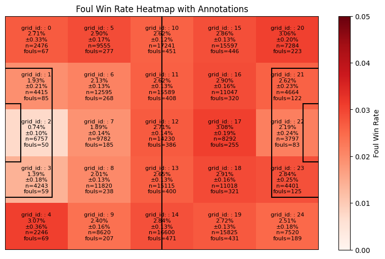

```python
plot_foul_win_rate_grid_heatmap(grid_frate_df, x_bins, y_bins)
```

**Important to note** that the coordinates used for the grid are where possession event started, not where foul actually occured at end of possession sequence

## Feature Engineering - FX

Lets convert events dataframe into dict such that quick lookups on 'id' key to get event fields and also want to preserve order so can quickly get previous events to build features from

### FX helper setup - convert event and match dfs to dics

Noticed some id's are incorrectly assumed to be floats in pandas, ensure integers

```python
cols_to_convert = [
    "position.id",
    "player.id",
]

for col in cols_to_convert:
    events_df[col] = events_df[col].astype("Int64")
```

```python
events_df[["position.id", "player.id"]].iloc[3:8]
```

|  | position.id | player.id |
| --- | --- | --- |
| 3 | <NA> | <NA> |
| 4 | 2 | 3608 |
| 5 | 23 | 15996 |
| 6 | 19 | 3057 |
| 7 | 19 | 3057 |

Want to store index in the dics as values as may be useful, and use the event 'id' as dic key.

```python
events_df[["timestamp", "index", "match_id"]].head()
```

|  | timestamp | index | match_id |
| --- | --- | --- | --- |
| 0 | 00:00:00.000 | 1 | 3753972 |
| 1 | 00:00:00.000 | 2 | 3753972 |
| 2 | 00:00:00.000 | 3 | 3753972 |
| 3 | 00:00:00.000 | 4 | 3753972 |
| 4 | 00:00:00.178 | 1770 | 3753972 |

```python
del events_df["index"]  # remove old index column
events_df = events_df.reset_index()
```

```python
%%time
events_dic = events_df.set_index("id").to_dict(orient="index")
```

```
CPU times: user 33.6 s, sys: 1.59 s, total: 35.1 s
Wall time: 35.4 s
```

Do same for matches_df to convert to dic

```python
%%time
matches_df = matches_df.reset_index()  # want index col explicitly so dont drop
matches_dic = matches_df.set_index("match_id").to_dict(orient="index")
```

```
CPU times: user 10.2 ms, sys: 2.79 ms, total: 12.9 ms
Wall time: 14.4 ms
```

### Simple features (start possess event)

```python
test_id = "e7f3536d-3209-4ed2-a3a4-cd1519e44f7f"
```

```python
def simple_single_fx(the_id, events_dic):
    """
    Extract and compute simple features from start possession event.

    Parameters:
    -----------
    the_id : str
        The unique identifier for the event.
    events_dic : dict
        Dictionary containing event data, where keys are event IDs and values are dictionaries of event attributes.

    Returns:
    --------
    fx_simple_dic : dict
        A dictionary containing simplified features derived from the event:
            - period: int (1 or 2, representing the half)
            - minute: int (match minute of the event)
            - x: float (x-coordinate on the pitch)
            - y: float (y-coordinate on the pitch)
            - is_recovery: int (1 if event is a 'Ball Recovery', else 0)
            - under_pressure: int (1 if event is under pressure, else 0)
    """
    event_dic = events_dic.get(the_id)
    if event_dic is None:
        raise ValueError(f"Event ID {the_id} not found in events_dic")

    # Determine if event is a 'Ball Recovery'
    type_name = event_dic.get("type.name", "")
    is_recovery = 1 if type_name == "Ball Recovery" else 0

    # Parse x and y coordinates from location string
    location = event_dic.get("location", "")
    x = float(location.split(",")[0].strip())
    y = float(location.split(",")[1].strip())

    # Convert 'under_pressure' to 0 (False) if missing or NaN, 1 (True) otherwise
    under_pressure = (
        0
        if event_dic.get("under_pressure") is np.nan
        else int(event_dic["under_pressure"])
    )

    # Build simplified feature dictionary
    fx_simple_dic = {
        "period": event_dic.get("period"),
        "minute": event_dic.get("minute"),
        "x": x,
        "y": y,
        "is_recovery": is_recovery,
        "under_pressure": under_pressure,
    }

    return fx_simple_dic
```

```python
simple_single_fx(test_id, events_dic)
```

```
{'period': 1,
 'minute': 0,
 'x': 60.2,
 'y': 40.7,
 'is_recovery': 0,
 'under_pressure': 0}
```

### Simple features from match data

```python
def match_simple_fx(the_id, events_dic, matches_dic):
    """
    Extract match-level feature(s) for a given event, such as whether the player was on the home team.

    Parameters:
    -----------
    the_id : str
        Unique identifier for the event.
    events_dic : dict
        Dictionary mapping event IDs to event data dictionaries.
    matches_dic : dict
        Dictionary mapping match IDs to match data dictionaries.

    Returns:
    --------
    fx_match_simple_dic : dict
        A dictionary with match-level features:
            - is_home_team: int (1 if the player was on the home team, 0 otherwise)
    """
    event_dic = events_dic.get(the_id)
    if event_dic is None:
        raise ValueError(f"Event ID {the_id} not found in events_dic")

    # Extract match and team identifiers
    match_id = event_dic["match_id"]
    player_team_id = event_dic["team.id"]
    match_dic = matches_dic.get(match_id)
    if match_dic is None:
        raise ValueError(f"Match ID {match_id} not found in matches_dic")

    home_team_id = match_dic.get("home_team.home_team_id")

    # Determine whether the player's team is the home team
    is_home_team = 1 if player_team_id == home_team_id else 0

    # Build output dictionary with match-level feature(s)
    fx_match_simple_dic = {"is_home_team": is_home_team}

    return fx_match_simple_dic
```

```python
match_simple_fx(test_id, events_dic, matches_dic)
```

```
{'is_home_team': 1}
```

### Basic distance-based features

```python
def dist_angle_on_pitch(x1, y1, x2, y2):
    """
    Calculate the Euclidean distance and angle between two points on a soccer pitch.

    Parameters:
    - x1, y1: Coordinates of the first point (e.g., starting position)
    - x2, y2: Coordinates of the second point (e.g., ending position)

    Returns:
    - distance: Euclidean distance between the points
    - angle_deg: Angle in degrees from (x1, y1) to (x2, y2), 0° is right, 90° is up
    """
    dx = x2 - x1
    dy = y2 - y1
    distance = round(math.hypot(dx, dy), 1)
    angle_rad = math.atan2(dy, dx)
    angle_deg = round(math.degrees(angle_rad), 1)
    return distance, angle_deg
```

```python
dist_angle_on_pitch(x1=15.7, y1=8.7, x2=120, y2=40)
```

```
(108.9, 16.7)
```

```python
def distance_simple_fx(the_id, events_dic):
    event_dic = events_dic.get(the_id)
    if event_dic is None:
        raise ValueError(f"Event ID {the_id} not found in events_dic")

    # Parse x and y coordinates from location string
    location = event_dic.get("location", "")
    x = float(location.split(",")[0].strip())
    y = float(location.split(",")[1].strip())

    opp_goal_center_x = 120
    opp_goal_center_y = 40
    dist_opp_goal, angle_opp_goal = dist_angle_on_pitch(
        x, y, opp_goal_center_x, opp_goal_center_y
    )

    # Build simplified feature dictionary
    fx_dist_simple_dic = {
        "dist_opp_goal": dist_opp_goal,
        "angle_opp_goal": angle_opp_goal,
    }

    return fx_dist_simple_dic
```

```python
distance_simple_fx(test_id, events_dic)
```

```
{'dist_opp_goal': 59.8, 'angle_opp_goal': -0.7}
```

### Foul rate features

Want to look at per team, player, position, and play_pattern foul win rates as features.

Also look at foul commited rates for opposing teams

Note that these are total foul won rate vs total events by offensive events by that team, not just based on first sequence

#### Calculate historical foul rate metrics on training dataset

Want to first ensure only caluclating these metrics on the training dataset which is valid since time-based split. So when evaluating on test set no leakage.

```python
train_df_match_ids = train_res_poss_df["match_id"].values
print(len(train_df_match_ids))
```

```
240729
```

```python
train_match_events_df = events_df[events_df["match_id"].isin(train_df_match_ids)]
print(train_match_events_df.shape)
```

```
(1047566, 50)
```

```python
def build_event_count_df(events_df, group_by_col, event_types):
    """
    Creates a DataFrame grouped by a specified column (e.g., 'team.id') with counts
    for each event type (e.g., 'Foul Won', 'Pass') from the 'type.name' column.

    Parameters:
    - events_df: DataFrame with event data
    - group_by_col: str, column name to group by (e.g., 'team.id', 'player.id')
    - event_types: list of str, event types to count (from 'type.name')

    Returns:
    - pd.DataFrame with group_by_col and one column per event_type
    """
    result_df = pd.DataFrame({group_by_col: events_df[group_by_col].unique()})

    for event in event_types:
        counts = (
            events_df[events_df["type.name"] == event][group_by_col]
            .value_counts()
            .rename(event)
            .reset_index()
            .rename(columns={"index": group_by_col})
        )
        result_df = result_df.merge(counts, on=group_by_col, how="left")

    result_df.fillna(0, inplace=True)
    result_df[event_types] = result_df[event_types].astype(int)

    return result_df
```

```python
def get_foul_rate_df(events_df, group_by_col, dropna=True, min_possessions=100):
    """
    Builds a DataFrame grouped by the specified column (e.g., 'team.id', 'position.id'),
    counting key event types and calculating estimated foul rates.

    Parameters:
    - events_df: pd.DataFrame, the match events data
    - group_by_col: str, column to group by (e.g., 'team.id', 'position.id')
    - dropna: bool, whether to drop rows with NaN values

    Returns:
    - pd.DataFrame with counts for each event type and foul rate columns:
      'est_foul_won_rate' and 'est_foul_commit_rate'
    """
    # Define event types needed for foul rate calculation
    event_types = ["Foul Committed", "Foul Won", "Ball Receipt*", "Ball Recovery"]
    # Count specified event types per group
    frate_df = build_event_count_df(
        events_df, group_by_col=group_by_col, event_types=event_types
    )
    # Calculate total possessions (denominator for rate calculations)
    total_possessions = frate_df["Ball Receipt*"] + frate_df["Ball Recovery"]
    frate_df["total_possessions"] = total_possessions

    # Estimate foul rates
    frate_df["est_foul_win_rate"] = (frate_df["Foul Won"] / total_possessions).round(3)
    frate_df["est_foul_commit_rate"] = (
        frate_df["Foul Committed"] / total_possessions
    ).round(3)
    if dropna:
        frate_df = frate_df.dropna()

    # Compute averages across qualifying rows (those above threshold)
    valid_rows = frate_df["total_possessions"] >= min_possessions
    avg_est_foul_won_rate = frate_df.loc[valid_rows, "est_foul_win_rate"].mean()
    avg_est_foul_commit_rate = frate_df.loc[valid_rows, "est_foul_commit_rate"].mean()

    # Replace values with averages where possessions are below threshold
    frate_df.loc[~valid_rows, "est_foul_win_rate"] = avg_est_foul_won_rate
    frate_df.loc[~valid_rows, "est_foul_commit_rate"] = avg_est_foul_commit_rate

    frate_df[group_by_col] = frate_df[group_by_col].astype("int")

    return frate_df.sort_values(group_by_col).reset_index(drop=True)
```

Create dataframes which have all the metrics per entity (team, player, position, etc..)

```python
team_frate_df = get_foul_rate_df(train_match_events_df, "team.id")
print(team_frate_df.shape)

# set a minimum possession to smooth things out, replace with global average if not enough samples
posi_frate_df = get_foul_rate_df(
    train_match_events_df, "position.id", min_possessions=500
)
print(posi_frate_df.shape)


player_frate_df = get_foul_rate_df(
    train_match_events_df, "player.id", min_possessions=100
)
print(player_frate_df.shape)

play_patt_frate_df = get_foul_rate_df(
    train_match_events_df, "play_pattern.id", min_possessions=100
)
print(play_patt_frate_df.shape)
```

```
(20, 8)
(23, 8)
(518, 8)
(9, 8)
```

```python
team_frate_dic = team_frate_df.set_index("team.id").to_dict(orient="index")
position_frate_dic = posi_frate_df.set_index("position.id").to_dict(orient="index")
player_frate_dic = player_frate_df.set_index("player.id").to_dict(orient="index")
play_patt_frate_dic = play_patt_frate_df.set_index("play_pattern.id").to_dict(
    orient="index"
)
```

#### Generate foul rate feature vectors

```python
def frate_fx(
    the_id,
    events_dic,
    matches_dic,
    team_frate_dic,
    position_frate_dic,
    player_frate_dic,
    play_patt_frate_dic,
    default_win_rate=0.025,
):
    """
    Extract foul-rate related features for a given event with fallback to overall averages.

    Parameters:
    - the_id: str, ID of the event
    - *_frate_dic: dict, mapping IDs to rate dictionaries
    - default_win_rate: float, fallback to global avg value if key is missing from its respective dict

    Returns:
    - frate_fx_dic: dict with foul rate features
    """
    event_dic = events_dic.get(the_id)
    if event_dic is None:
        raise ValueError(f"Event ID {the_id} not found in events_dic")

    match_id = event_dic["match_id"]
    player_team_id = event_dic["team.id"]

    try:
        position_id = int(event_dic["position.id"])
        player_id = int(event_dic["player.id"])
        play_pattern_id = int(event_dic["play_pattern.id"])
    except (TypeError, ValueError) as e:
        raise ValueError(f"Invalid ID type in event {the_id}: {e}")

    match_dic = matches_dic.get(match_id)
    if match_dic is None:
        raise ValueError(f"Match ID {match_id} not found in matches_dic")

    home_team_id = match_dic.get("home_team.home_team_id")
    away_team_id = match_dic.get("away_team.away_team_id")

    # Determine opposing team
    if player_team_id == home_team_id:
        opp_team_id = away_team_id
    elif player_team_id == away_team_id:
        opp_team_id = home_team_id
    else:
        raise ValueError(f"Team ID {player_team_id} not found in match {match_id}")

    # Lookup with fallbacks
    team_foul_win_rate = team_frate_dic.get(player_team_id, {}).get(
        "est_foul_win_rate", default_win_rate
    )
    position_foul_win_rate = position_frate_dic.get(position_id, {}).get(
        "est_foul_win_rate", default_win_rate
    )
    player_foul_win_rate = player_frate_dic.get(player_id, {}).get(
        "est_foul_win_rate", default_win_rate
    )
    play_patt_foul_win_rate = play_patt_frate_dic.get(play_pattern_id, {}).get(
        "est_foul_win_rate", default_win_rate
    )
    opp_team_foul_commit_rate = team_frate_dic.get(opp_team_id, {}).get(
        "est_foul_commit_rate", default_win_rate
    )

    frate_fx_dic = {
        "team_foul_win_rate": team_foul_win_rate,
        "position_foul_win_rate": position_foul_win_rate,
        "player_foul_win_rate": player_foul_win_rate,
        "play_patt_foul_win_rate": play_patt_foul_win_rate,
        "opp_team_foul_commit_rate": opp_team_foul_commit_rate,
    }

    return frate_fx_dic
```

```python
frate_fx(
    test_id,
    events_dic,
    matches_dic,
    team_frate_dic,
    position_frate_dic,
    player_frate_dic,
    play_patt_frate_dic,
)
```

```
{'team_foul_win_rate': 0.025,
 'position_foul_win_rate': 0.028,
 'player_foul_win_rate': 0.009,
 'play_patt_foul_win_rate': 0.015,
 'opp_team_foul_commit_rate': 0.021}
```

### Pitch grid spatial foul win rate features

recap from EDA foul rates on pitch

```python
grid_frate_df, x_bins, y_bins = compute_foul_win_rate_grid(
    train_res_poss_df, bins=(5, 5)
)
```

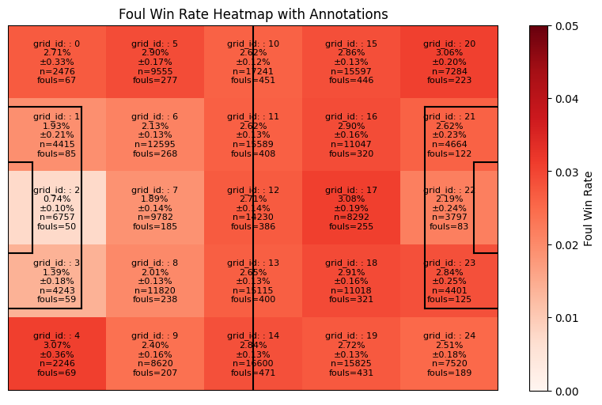

```python
plot_foul_win_rate_grid_heatmap(grid_frate_df, x_bins, y_bins)
```

```python
grid_frate_df.head()
```

|  | x_bin | y_bin | total_poss_count | foul_win_count | foul_win_rate | foul_win_rate_std | grid_id |
| --- | --- | --- | --- | --- | --- | --- | --- |
| 0 | 0 | 0 | 2476 | 67 | 0.027060 | 0.003261 | 0 |
| 1 | 0 | 1 | 4415 | 85 | 0.019253 | 0.002068 | 1 |
| 2 | 0 | 2 | 6757 | 50 | 0.007400 | 0.001043 | 2 |
| 3 | 0 | 3 | 4243 | 59 | 0.013905 | 0.001798 | 3 |
| 4 | 0 | 4 | 2246 | 69 | 0.030721 | 0.003641 | 4 |

```python
# convert dataframe into dictionary with grid_id as key
grid_frate_dic = grid_frate_df.set_index("grid_id").to_dict(orient="index")
```

```python
grid_frate_dic[0]
```

```
{'x_bin': 0,
 'y_bin': 0,
 'total_poss_count': 2476,
 'foul_win_count': 67,
 'foul_win_rate': 0.02705977382875606,
 'foul_win_rate_std': 0.003260842635995429}
```

```python
def get_grid_id_from_coordinate(x, y, x_bins, y_bins):
    """
    Given a coordinate (x, y), return the grid_id it falls into based on x_bins and y_bins.

    Returns:
        bin_id (int), or None if out of bounds.
    """
    x_bin = np.digitize([x], x_bins, right=False)[0] - 1
    y_bin = np.digitize([y], y_bins, right=False)[0] - 1

    if 0 <= x_bin < len(x_bins) - 1 and 0 <= y_bin < len(y_bins) - 1:
        num_y_bins = len(y_bins) - 1
        grid_id = x_bin * num_y_bins + y_bin
        return grid_id
    else:
        # should be very rare case if ever if coordinate outside football pitch dimensions
        # if so just put grid=12 center
        return 12
```

```python
grid_id = get_grid_id_from_coordinate(45.0, 30.0, x_bins, y_bins)
print(f"Grid ID: {grid_id}")
grid_id = get_grid_id_from_coordinate(450, 30.0, x_bins, y_bins)  # test outside range
print(f"Grid ID: {grid_id}")
```

```
Grid ID: 6
Grid ID: 12
```

```python
def get_grid_frate_metrics(grid_id, grid_frate_dic):
    grid_metrics_dic = grid_frate_dic[grid_id]

    grid_frate_metrics_dic = {
        "grid_id": grid_id,
        "grid_total_count": grid_metrics_dic["total_poss_count"],
        "grid_foul_count": grid_metrics_dic["foul_win_count"],
        "grid_foul_rate": grid_metrics_dic["foul_win_rate"],
        "grid_foul_rate_std": grid_metrics_dic["foul_win_rate_std"],
    }

    return grid_frate_metrics_dic
```

```python
def grid_frate_fx(the_id, events_dic, x_bins, y_bins, grid_frate_dic):
    event_dic = events_dic.get(the_id)
    if event_dic is None:
        raise ValueError(f"Event ID {the_id} not found in events_dic")

    # Parse x and y coordinates from location string
    location = event_dic.get("location", "")
    x = float(location.split(",")[0].strip())
    y = float(location.split(",")[1].strip())

    # get which grid belongs too
    grid_id = get_grid_id_from_coordinate(x, y, x_bins, y_bins)

    # get grid metrics
    grid_frate_metrics_dic = get_grid_frate_metrics(grid_id, grid_frate_dic)

    grid_frate_fx_dic = grid_frate_metrics_dic

    return grid_frate_fx_dic
```

```python
grid_frate_fx(test_id, events_dic, x_bins, y_bins, grid_frate_dic)
```

```
{'grid_id': np.int64(12),
 'grid_total_count': 14230,
 'grid_foul_count': 386,
 'grid_foul_rate': 0.027125790583274773,
 'grid_foul_rate_std': 0.0013618118142104132}
```

### Previous events features - time-based and proximity based

We want to look at the count and type and locations of events preceding the valid start possession event

- for example, things like was there any duels that happended within 1 second of the event and within 20 distance? Could be potentially useful context for model to learn from
- additionally look at some of the pass-specific fields as features for cases where pass before ball receipt of possession start event
- check if any 'counterpressure' = True
- check how many unique 'possessions'

**Note** - This ended up a bit more complicated to implement than I liked, so code could be optimized more and cleaned up in the future

#### Setup input data

Dont want to mess with previous original events_df so creating a copy and doing some setup since more complex fx workflow for these time+proximity previous events features

```python
def time_to_seconds(row):
    return row["minute"] * 60 + row["second"] + (row["period"] - 1) * 2700
```

```python
tmp_event_df = events_df.copy()
tmp_event_df = tmp_event_df.set_index("id")
# absolute seconds since start of match
tmp_event_df["abs_time_secs"] = tmp_event_df.apply(time_to_seconds, axis=1)
tmp_event_df["x"] = tmp_event_df["location"].apply(
    lambda s: float(s.split(",")[0].strip()) if pd.notnull(s) else None
)
tmp_event_df["y"] = tmp_event_df["location"].apply(
    lambda s: float(s.split(",")[1].strip()) if pd.notnull(s) else None
)
tmp_event_df["possess_team_event"] = (
    tmp_event_df["possession_team.name"] == tmp_event_df["team.name"]
)

# the following fixes the mirror issue to ensure non-possess team player locations align with poss team player locations
tmp_event_df["x"] = np.where(
    tmp_event_df["possess_team_event"], tmp_event_df["x"], 120 - tmp_event_df["x"]
)
tmp_event_df["y"] = np.where(
    tmp_event_df["possess_team_event"], tmp_event_df["y"], 80 - tmp_event_df["y"]
)
```

#### Define helper functions

Note that originally I included all the target events and generated the time + proximity features for them but after looking at SHAP values for feature importance none of them were important other than pressure related ones. so updated to exclude others

```python
TARGET_EVENT_TYPES = [
    "Pressure",
    # "Duel",
    # "Clearance",
    # "Block",
    # "Miscontrol",
    # "Interception",
    # "Dribbled Past",
]
```

```python
def get_preceding_rows_by_seconds(
    df: pd.DataFrame, the_id: str, seconds: float, lookback_limit: int = 30
) -> pd.DataFrame:
    """
    Return all preceding events within a given time window for the same match.

    Parameters:
    -----------
    df : pd.DataFrame
        The events DataFrame indexed by 'id'. Must include columns:
        - 'abs_time_secs': absolute time of each event in seconds
        - 'match_id': match identifier
    the_id : str
        The index value (event ID) for which we want to extract preceding events.
    seconds : float
        Time window in seconds to look back.

    Returns:
    --------
    pd.DataFrame
        A new DataFrame with all events that occurred within `seconds` before
        the target event, limited to the same match, and indexed by 'id'.
        Returned rows are in ascending time order.
    """

    if df.index.name != "id":
        raise ValueError("DataFrame must have 'id' as its index")

    if the_id not in df.index:
        return df.iloc[0:0]

    loc = df.index.get_loc(the_id)
    if isinstance(loc, slice) or isinstance(loc, list):
        raise ValueError("Row ID must be unique")

    target_row = df.iloc[loc]
    target_time = target_row["abs_time_secs"]
    target_match = target_row["match_id"]

    # Pull a fixed number of rows before current one
    start_idx = max(0, loc - lookback_limit)
    candidate_df = df.iloc[start_idx:loc]

    # Filter by match_id and time window
    mask = (candidate_df["match_id"] == target_match) & (
        candidate_df["abs_time_secs"] >= target_time - seconds
    )
    return candidate_df[mask]
```

```python
tmp_event_df[tmp_event_df.index == "ec0b4585-41ad-4ada-817c-629d0866eeeb"][
    ["timestamp", "period", "abs_time_secs", "type.name"]
]
```

| id | timestamp | period | abs_time_secs | type.name |
| --- | --- | --- | --- | --- |
| ec0b4585-41ad-4ada-817c-629d0866eeeb | 00:00:01.808 | 1 | 1 | Ball Receipt* |

```python
# test get preceding rows by timestamp works (last 3 seconds before)
get_preceding_rows_by_seconds(tmp_event_df, "ec0b4585-41ad-4ada-817c-629d0866eeeb", 3)[
    ["timestamp", "period", "abs_time_secs", "type.name"]
]
```

| id | timestamp | period | abs_time_secs | type.name |
| --- | --- | --- | --- | --- |
| 6bbafb9c-9e4f-45bf-80f2-6f93c8b4d5e2 | 00:00:00.000 | 1 | 0 | Starting XI |
| 07aa1c9f-aff7-42aa-b763-39a478b8e5ea | 00:00:00.000 | 1 | 0 | Starting XI |
| a893074f-957f-4272-8d64-92020f98337f | 00:00:00.000 | 1 | 0 | Half Start |
| 0ee3b84e-9975-48e0-819a-daeee9dc8880 | 00:00:00.000 | 1 | 0 | Half Start |
| d44ad288-509f-4957-9754-9aa361bc316b | 00:00:00.178 | 1 | 0 | Ball Receipt* |
| b1c7e9af-19b2-47d8-855f-14aa3209648c | 00:00:00.548 | 1 | 0 | Pass |
| e7f3536d-3209-4ed2-a3a4-cd1519e44f7f | 00:00:00.898 | 1 | 0 | Ball Receipt* |
| 575d8b5a-1b10-4f34-98df-579cc0a52a2e | 00:00:00.898 | 1 | 0 | Pass |
| 70fc4868-b11b-4f0d-adc7-1e819aa8abe9 | 00:00:01.731 | 1 | 1 | Pressure |

```python
def count_event_types_in_time_window(
    df: pd.DataFrame, the_id: str, seconds: float
) -> Dict[str, int]:
    """
    Count the number of occurrences for each target event type within a time window
    preceding the specified event.

    Parameters:
    -----------
    df : pd.DataFrame
        Events DataFrame indexed by 'id', must include 'type.name' and 'abs_time_secs'.
    the_id : str
        The event ID to look back from.
    seconds : float
        Time window (in seconds) to consider before the target event.

    Returns:
    --------
    Dict[str, int]
        A dictionary mapping each event type in TARGET_EVENT_TYPES to its count
        within the specified time window.
    """
    # Get preceding events within the time window
    preceding = get_preceding_rows_by_seconds(df, the_id, seconds)
    # Count event type occurrences
    type_counts = Counter(preceding["type.name"])
    # Ensure all TARGET_EVENT_TYPES are included with default count of 0
    return {k: type_counts.get(k, 0) for k in TARGET_EVENT_TYPES}
```

```python
def count_unique_possessions_in_time_window(
    df: pd.DataFrame, the_id: str, seconds: float
) -> int:
    """
    Count the number of unique possession IDs in a time window preceding the event.

    Parameters:
    -----------
    df : pd.DataFrame
        Events DataFrame indexed by 'id', must include 'possession' and 'abs_time_secs'.
    the_id : str
        The event ID to look back from.
    seconds : float
        Time window (in seconds) to consider before the target event.

    Returns:
    --------
    int
        The number of unique possessions in the time window (minimum 1).
    """
    # Get preceding events within the time window
    preceding = get_preceding_rows_by_seconds(df, the_id, seconds)
    # Clean and extract unique possession IDs
    possession_values = (
        pd.to_numeric(preceding["possession"], errors="coerce")  # ensure numeric
        .dropna()  # remove NaNs
        .astype(int)  # cast to int
        .unique()  # get unique values
    )
    # Return at least 1 to avoid divide-by-zero errors downstream
    return max(1, len(possession_values))
```

```python
def count_counterpress_in_time_window(
    df: pd.DataFrame, the_id: str, seconds: float
) -> int:
    """
    Count how many of the preceding events are marked as 'counterpress' == True.

    Parameters:
    -----------
    df : pd.DataFrame
        Events DataFrame indexed by 'id', must include 'counterpress' and 'abs_time_secs'.
    the_id : str
        The event ID to look back from.
    seconds : float
        Time window (in seconds) to consider before the target event.

    Returns:
    --------
    int
        Number of preceding events with 'counterpress' == True.
    """
    # Get preceding events within the time window
    preceding = get_preceding_rows_by_seconds(df, the_id, seconds)
    # Count events where counterpress is explicitly True
    return (preceding["counterpress"] == True).sum()
```

```python
def get_preceding_pass_features(
    df: pd.DataFrame, row_id: str
) -> Optional[Dict[str, Any]]:
    """
    Extract pass-related features from the event immediately before the given row,
    if that event is of type 'Pass'. Returns key pass details or None if not applicable.

    Parameters:
    -----------
    df : pd.DataFrame
        Events DataFrame indexed by 'id'. Should include:
        - 'type.name', 'pass.angle', 'pass.height.id',
          'pass.body_part.id', and 'pass.end_location'

    row_id : str
        ID of the current event for which to extract preceding pass data.

    Returns:
    --------
    Dict[str, Any] or None
        Dictionary of preceding pass features, or None if not a pass or unavailable.
    """
    try:
        loc = df.index.get_loc(row_id)
        if loc == 0:
            return None
        prev_row = df.iloc[loc - 1]
        if prev_row["type.name"] == "Pass":
            return {
                "pass.angle": prev_row.get("pass.angle"),
                "pass.height.id": prev_row.get("pass.height.id"),
                "pass.body_part.id": prev_row.get("pass.body_part.id"),
                # "pass.end_location": prev_row.get("pass.end_location"),
            }
    except Exception:
        return None
    return None
```

```python
def count_event_types_in_time_distance(
    df: pd.DataFrame, the_id: str, seconds: float, max_dist: float
) -> Dict[str, int]:
    """
    Count how many preceding events of each type occurred within a specified time
    window and spatial distance from a target event.

    Parameters:
    -----------
    df : pd.DataFrame
        Events DataFrame indexed by 'id'. Must include columns:
        - 'abs_time_secs' for absolute event time in seconds,
        - 'x' and 'y' for event coordinates,
        - 'type.name' for event type names.
    the_id : str
        ID of the target event to look back from.
    seconds : float
        Time window (in seconds) to consider before the target event.
    max_dist : float
        Maximum spatial distance (in pitch units, e.g., meters) from the target event.

    Returns:
    --------
    Dict[str, int]
        A dictionary mapping each event type in TARGET_EVENT_TYPES to the number
        of times it occurred within both the time window and distance threshold.
    """
    # If the_id is missing from the DataFrame, return 0s
    if the_id not in df.index:
        return {k: 0 for k in TARGET_EVENT_TYPES}
    # Get the target event's location
    target = df.loc[the_id]
    x0, y0 = target["x"], target["y"]
    # If target event has no valid location, return 0s
    if pd.isna(x0) or pd.isna(y0):
        return {k: 0 for k in TARGET_EVENT_TYPES}

    nearby_types = []

    # Get all preceding events within the time window
    preceding = get_preceding_rows_by_seconds(df, the_id, seconds)
    # Loop through each preceding event and check spatial proximity
    for _, row in preceding.iterrows():
        x, y = row["x"], row["y"]
        if pd.notna(x) and pd.notna(y):
            # Compute Euclidean distance
            dist, _ = dist_angle_on_pitch(x0, y0, x, y)
            if dist <= max_dist:
                nearby_types.append(row["type.name"])

    # Count occurrences of event types within distance
    type_counts = Counter(nearby_types)
    # Ensure all TARGET_EVENT_TYPES are represented
    return {k: type_counts.get(k, 0) for k in TARGET_EVENT_TYPES}
```

#### Previous events - fx batch run

my current implementation is slow to run single event at a time as part of main fx, so need to faster precompute in batches to reference later for now.

if time permitted more, I would revisit my code to try and optimize and clean up

```python
def batch_prev_events_fx(
    events_df: pd.DataFrame, the_ids: list[str]
) -> Dict[str, Dict[str, Any]]:
    """
    Batch version of prev_events fx that processes all events grouped by match.
    Reduces DataFrame slicing overhead by working in bulk.

    Parameters:
        events_df: Full events dataframe, must be sorted by match_id and abs_time_secs.
        the_ids: List of event 'id' values to compute features for.

    Returns:
        A dictionary mapping each row_id to its features.
    """
    result = {}
    lookback_limit = 30
    time_windows = [1, 3, 5]
    proximity_thresholds = [10, 30]

    id_set = set(the_ids)

    for match_id, group in events_df.groupby("match_id"):
        group = group.sort_values("abs_time_secs")
        ids = group.index.tolist()
        times = group["abs_time_secs"].to_numpy()
        types = group["type.name"].tolist()
        xs = group["x"].to_numpy()
        ys = group["y"].to_numpy()
        possessions = group["possession"].to_numpy()
        counterpress = group["counterpress"].to_numpy()

        for i, row_id in enumerate(ids):
            if row_id not in id_set:
                continue

            feature_row = {}
            target_time = times[i]
            x0, y0 = xs[i], ys[i]

            for sec in time_windows:
                prefix = f"sec{str(sec).replace('.', '_')}"
                j_start = max(0, i - lookback_limit)

                # Filter time window
                mask = times[j_start:i] >= target_time - sec
                window_types = [
                    types[j] for j in range(j_start, i) if mask[j - j_start]
                ]
                window_possessions = [
                    possessions[j] for j in range(j_start, i) if mask[j - j_start]
                ]
                window_counterpress = [
                    counterpress[j] for j in range(j_start, i) if mask[j - j_start]
                ]
                type_counter = Counter(window_types)

                for k in TARGET_EVENT_TYPES:
                    feature_row[f"{prefix}_count_type_{k}"] = type_counter.get(k, 0)

                feature_row[f"{prefix}_unique_possessions"] = max(
                    1, len(set(p for p in window_possessions if pd.notna(p)))
                )
                feature_row[f"{prefix}_counterpress_true"] = sum(
                    1 for val in window_counterpress if val is True
                )

                for dist_thresh in proximity_thresholds:
                    nearby_types = []
                    for j in range(j_start, i):
                        if not mask[j - j_start]:
                            continue
                        x, y = xs[j], ys[j]
                        if (
                            pd.notna(x)
                            and pd.notna(y)
                            and pd.notna(x0)
                            and pd.notna(y0)
                        ):
                            dist = math.hypot(x - x0, y - y0)
                            if dist <= dist_thresh:
                                nearby_types.append(types[j])
                    dist_counter = Counter(nearby_types)
                    for k in TARGET_EVENT_TYPES:
                        feature_row[f"{prefix}_dist{dist_thresh}_type_{k}"] = (
                            dist_counter.get(k, 0)
                        )

            if i > 0 and types[i - 1] == "Pass":
                prev_row = group.iloc[i - 1]
                feature_row.update(
                    {
                        "pass.angle": prev_row.get("pass.angle"),
                        "pass.height.id": prev_row.get("pass.height.id"),
                        "pass.body_part.id": prev_row.get("pass.body_part.id"),
                    }
                )

            result[row_id] = feature_row

    return result
```

```python
# test single event
batch_prev_events_fx(tmp_event_df, ["8ca81a7e-16f4-4c51-a708-bfcbbd63e1b2"])
```

```
{'8ca81a7e-16f4-4c51-a708-bfcbbd63e1b2': {'sec1_count_type_Pressure': 1,
  'sec1_unique_possessions': 1,
  'sec1_counterpress_true': 0,
  'sec1_dist10_type_Pressure': 1,
  'sec1_dist30_type_Pressure': 1,
  'sec3_count_type_Pressure': 1,
  'sec3_unique_possessions': 1,
  'sec3_counterpress_true': 0,
  'sec3_dist10_type_Pressure': 1,
  'sec3_dist30_type_Pressure': 1,
  'sec5_count_type_Pressure': 2,
  'sec5_unique_possessions': 1,
  'sec5_counterpress_true': 1,
  'sec5_dist10_type_Pressure': 2,
  'sec5_dist30_type_Pressure': 2,
  'pass.angle': np.float64(3.113431),
  'pass.height.id': np.float64(1.0),
  'pass.body_part.id': np.float64(40.0)}}
```

```python
train_event_ids = train_res_poss_df["id"].values
print(len(train_event_ids))
```

```
240729
```

```python
%%time
prev_train_fx_dic = batch_prev_events_fx(tmp_event_df, train_event_ids)
print(len(prev_train_fx_dic))
```

```
240729
CPU times: user 53.3 s, sys: 616 ms, total: 53.9 s
Wall time: 54.3 s
```

```python
test_event_ids = test_res_poss_df["id"].values
print(len(test_event_ids))
```

```
60162
```

```python
%%time
prev_test_fx_dic = batch_prev_events_fx(tmp_event_df, test_event_ids)
print(len(prev_test_fx_dic))
```

```
60162
CPU times: user 14.6 s, sys: 327 ms, total: 14.9 s
Wall time: 15 s
```

```python
# prev_test_fx_dic.get(test_event_ids[400])
```

join train and test into single dictionary

```python
prev_events_fx_dic = prev_train_fx_dic | prev_test_fx_dic
print(len(prev_events_fx_dic))
```

```
300891
```

```python
prev_events_fx_dic.get(test_event_ids[400])
```

```
{'sec1_count_type_Pressure': 0,
 'sec1_unique_possessions': 1,
 'sec1_counterpress_true': 0,
 'sec1_dist10_type_Pressure': 0,
 'sec1_dist30_type_Pressure': 0,
 'sec3_count_type_Pressure': 1,
 'sec3_unique_possessions': 2,
 'sec3_counterpress_true': 0,
 'sec3_dist10_type_Pressure': 0,
 'sec3_dist30_type_Pressure': 0,
 'sec5_count_type_Pressure': 2,
 'sec5_unique_possessions': 2,
 'sec5_counterpress_true': 0,
 'sec5_dist10_type_Pressure': 0,
 'sec5_dist30_type_Pressure': 0}
```

### Full FX - generate all feature vectors

fx() function takes in each event_id as input and returns feature vector as a dictionary

```python
def fx(
    the_id,
    events_dic,
    matches_dic,
    team_frate_dic,
    position_frate_dic,
    player_frate_dic,
    play_patt_frate_dic,
    prev_events_fx_dic,
):
    """
    Generate a combined feature dictionary for a given event, including both event-level
    and match-level features.

    Parameters:
    -----------
    the_id : str
        Unique identifier for the event.
    events_dic : dict
        Dictionary mapping event IDs to event data dictionaries.
    matches_dic : dict
        Dictionary mapping match IDs to match data dictionaries.
    team_frate_dic : dict
        Dictionary mapping team IDs to foul rate stats.
    position_frate_dic : dict
        Dictionary mapping position IDs to foul rate stats.
    player_frate_dic : dict
        Dictionary mapping player IDs to foul rate stats.
    play_patt_frate_dic : dict
        Dictionary mapping play pattern IDs to foul rate stats.
    prev_events_fx_dic: dict
        Dictionary with id key which gives all 'previous events' features as returned dic

    Returns:
    --------
    final_fx_dic : dict
        A dictionary containing the merged features from:
            - simple_single_fx (single event-level features)
            - match_simple_fx (match-level features)
            - dist_simple_fx_dic (distance based features single event-level)
    """
    # Extract event-level features
    si_simple_fx_dic = simple_single_fx(the_id, events_dic)

    # Extract match-level features
    mat_simple_fx_dic = match_simple_fx(the_id, events_dic, matches_dic)

    # Extract simple-dist-based features
    dist_simple_fx_dic = distance_simple_fx(the_id, events_dic)

    # Extract foul-rate features
    frate_fx_dic = frate_fx(
        the_id,
        events_dic,
        matches_dic,
        team_frate_dic,
        position_frate_dic,
        player_frate_dic,
        play_patt_frate_dic,
    )

    # Extract grid foul rate based features
    grid_frate_fx_dic = grid_frate_fx(
        the_id, events_dic, x_bins, y_bins, grid_frate_dic
    )

    # Merge the many fx result dictionaries
    final_fx_dic = (
        si_simple_fx_dic
        | mat_simple_fx_dic
        | dist_simple_fx_dic
        | frate_fx_dic
        | grid_frate_fx_dic
        | prev_events_fx_dic[the_id]
    )

    return final_fx_dic
```

```python
# testing single sample (event)
fx(
    test_id,
    events_dic,
    matches_dic,
    team_frate_dic,
    position_frate_dic,
    player_frate_dic,
    play_patt_frate_dic,
    prev_events_fx_dic,
)
```

```
{'period': 1,
 'minute': 0,
 'x': 60.2,
 'y': 40.7,
 'is_recovery': 0,
 'under_pressure': 0,
 'is_home_team': 1,
 'dist_opp_goal': 59.8,
 'angle_opp_goal': -0.7,
 'team_foul_win_rate': 0.025,
 'position_foul_win_rate': 0.028,
 'player_foul_win_rate': 0.009,
 'play_patt_foul_win_rate': 0.015,
 'opp_team_foul_commit_rate': 0.021,
 'grid_id': np.int64(12),
 'grid_total_count': 14230,
 'grid_foul_count': 386,
 'grid_foul_rate': 0.027125790583274773,
 'grid_foul_rate_std': 0.0013618118142104132,
 'sec1_count_type_Pressure': 0,
 'sec1_unique_possessions': 2,
 'sec1_counterpress_true': 0,
 'sec1_dist10_type_Pressure': 0,
 'sec1_dist30_type_Pressure': 0,
 'sec3_count_type_Pressure': 0,
 'sec3_unique_possessions': 2,
 'sec3_counterpress_true': 0,
 'sec3_dist10_type_Pressure': 0,
 'sec3_dist30_type_Pressure': 0,
 'sec5_count_type_Pressure': 0,
 'sec5_unique_possessions': 2,
 'sec5_counterpress_true': 0,
 'sec5_dist10_type_Pressure': 0,
 'sec5_dist30_type_Pressure': 0,
 'pass.angle': np.float64(2.4980915),
 'pass.height.id': np.float64(1.0),
 'pass.body_part.id': np.float64(40.0)}
```

```python
print(train_res_poss_df.shape)
print(test_res_poss_df.shape)
```

```
(240729, 11)
(60162, 11)
```

```python
train_res_poss_df.head(2)
```

|  | match_id | id | period | timestamp | type.name | location | player.id | possession | player_possession | ends_in_foul | ml_split |
| --- | --- | --- | --- | --- | --- | --- | --- | --- | --- | --- | --- |
| 0 | 3753972 | e7f3536d-3209-4ed2-a3a4-cd1519e44f7f | 1 | 00:00:00.898 | Ball Receipt* | 60.2, 40.7 | 3057.0 | 2 | 6 | False | train |
| 1 | 3753972 | ec0b4585-41ad-4ada-817c-629d0866eeeb | 1 | 00:00:01.808 | Ball Receipt* | 52.4, 41.6 | 4631.0 | 2 | 7 | False | train |

```python
def build_fx_df(
    source_df,
    events_dic,
    matches_dic,
    team_frate_dic,
    position_frate_dic,
    player_frate_dic,
    play_patt_frate_dic,
    prev_events_fx_dic,
):
    fx_res_list = []
    for i in range(len(source_df)):
        row = source_df.iloc[i]
        the_id = row["id"]
        fx_res_dic = fx(
            the_id,
            events_dic,
            matches_dic,
            team_frate_dic,
            position_frate_dic,
            player_frate_dic,
            play_patt_frate_dic,
            prev_events_fx_dic,
        )
        fx_res_list.append(fx_res_dic)

    fx_df = pd.DataFrame(fx_res_list)
    return fx_df
```

```python
%%time
fx_train_df = build_fx_df(
    train_res_poss_df,
    events_dic,
    matches_dic,
    team_frate_dic,
    position_frate_dic,
    player_frate_dic,
    play_patt_frate_dic,
    prev_events_fx_dic,
)
print(fx_train_df.shape)
```

```
(240729, 37)
CPU times: user 24.9 s, sys: 999 ms, total: 25.9 s
Wall time: 25.6 s
```

```python
%%time
fx_test_df = build_fx_df(
    test_res_poss_df,
    events_dic,
    matches_dic,
    team_frate_dic,
    position_frate_dic,
    player_frate_dic,
    play_patt_frate_dic,
    prev_events_fx_dic,
)
print(fx_test_df.shape)
```

```
(60162, 37)
CPU times: user 6.36 s, sys: 221 ms, total: 6.58 s
Wall time: 6.49 s
```

```python
# fill NAs just in case for now
fx_train_df = fx_train_df.fillna(0)
fx_test_df = fx_test_df.fillna(0)
```

```python
fx_train_df.head()
```

|  | period | minute | x | y | is_recovery | under_pressure | is_home_team | dist_opp_goal | angle_opp_goal | team_foul_win_rate | position_foul_win_rate | player_foul_win_rate | play_patt_foul_win_rate | opp_team_foul_commit_rate | grid_id | grid_total_count | grid_foul_count | grid_foul_rate | grid_foul_rate_std | sec1_count_type_Pressure | sec1_unique_possessions | sec1_counterpress_true | sec1_dist10_type_Pressure | sec1_dist30_type_Pressure | sec3_count_type_Pressure | sec3_unique_possessions | sec3_counterpress_true | sec3_dist10_type_Pressure | sec3_dist30_type_Pressure | … |
| --- | --- | --- | --- | --- | --- | --- | --- | --- | --- | --- | --- | --- | --- | --- | --- | --- | --- | --- | --- | --- | --- | --- | --- | --- | --- | --- | --- | --- | --- | --- |
| 0 | 1 | 0 | 60.2 | 40.7 | 0 | 0 | 1 | 59.8 | -0.7 | 0.025 | 0.028 | 0.009 | 0.015 | 0.021 | 12 | 14230 | 386 | 0.027126 | 0.001362 | 0 | 2 | 0 | 0 | 0 | 0 | 2 | 0 | 0 | 0 | … |
| 1 | 1 | 0 | 52.4 | 41.6 | 0 | 1 | 1 | 67.6 | -1.4 | 0.025 | 0.020 | 0.024 | 0.015 | 0.021 | 12 | 14230 | 386 | 0.027126 | 0.001362 | 0 | 3 | 0 | 0 | 0 | 0 | 3 | 0 | 0 | 0 | … |
| 2 | 1 | 0 | 33.2 | 60.9 | 0 | 0 | 1 | 89.3 | -13.5 | 0.025 | 0.016 | 0.043 | 0.015 | 0.021 | 8 | 11820 | 238 | 0.020135 | 0.001292 | 0 | 1 | 0 | 0 | 0 | 1 | 1 | 0 | 0 | 0 | … |
| 3 | 1 | 0 | 28.5 | 31.1 | 0 | 0 | 1 | 91.9 | 5.6 | 0.025 | 0.017 | 0.011 | 0.015 | 0.021 | 6 | 12595 | 268 | 0.021278 | 0.001286 | 0 | 1 | 0 | 0 | 0 | 0 | 1 | 0 | 0 | 0 | … |
| 4 | 1 | 0 | 26.8 | 60.2 | 0 | 0 | 1 | 95.4 | -12.2 | 0.025 | 0.016 | 0.043 | 0.015 | 0.021 | 8 | 11820 | 238 | 0.020135 | 0.001292 | 0 | 1 | 0 | 0 | 0 | 0 | 1 | 0 | 0 | 0 | … |

```python
fx_train_df["sec5_counterpress_true"].value_counts()
```

```
sec5_counterpress_true
0    212338
1     19572
2      6506
3      1772
4       441
5        86
6        10
7         4
Name: count, dtype: int64
```

```python
fx_train_df.under_pressure.value_counts()
```

```
under_pressure
0    214671
1     26058
Name: count, dtype: int64
```

```python
fx_train_df["pass.height.id"].value_counts()
```

```
pass.height.id
0.0    133917
1.0     76608
2.0     15150
3.0     15054
Name: count, dtype: int64
```

```python
fx_train_df.is_recovery.value_counts()
```

```
is_recovery
0    212219
1     28510
Name: count, dtype: int64
```

```python
fx_test_df.head(2)
```

|  | period | minute | x | y | is_recovery | under_pressure | is_home_team | dist_opp_goal | angle_opp_goal | team_foul_win_rate | position_foul_win_rate | player_foul_win_rate | play_patt_foul_win_rate | opp_team_foul_commit_rate | grid_id | grid_total_count | grid_foul_count | grid_foul_rate | grid_foul_rate_std | sec1_count_type_Pressure | sec1_unique_possessions | sec1_counterpress_true | sec1_dist10_type_Pressure | sec1_dist30_type_Pressure | sec3_count_type_Pressure | sec3_unique_possessions | sec3_counterpress_true | sec3_dist10_type_Pressure | sec3_dist30_type_Pressure | … |
| --- | --- | --- | --- | --- | --- | --- | --- | --- | --- | --- | --- | --- | --- | --- | --- | --- | --- | --- | --- | --- | --- | --- | --- | --- | --- | --- | --- | --- | --- | --- |
| 0 | 1 | 0 | 60.7 | 42.1 | 0 | 0 | 1 | 59.3 | -2.0 | 0.026 | 0.024 | 0.022 | 0.015 | 0.027 | 12 | 14230 | 386 | 0.027126 | 0.001362 | 0 | 3 | 0 | 0 | 0 | 0 | 3 | 0 | 0 | 0 | … |
| 1 | 1 | 0 | 54.9 | 37.8 | 0 | 1 | 1 | 65.1 | 1.9 | 0.026 | 0.020 | 0.015 | 0.015 | 0.027 | 12 | 14230 | 386 | 0.027126 | 0.001362 | 1 | 1 | 0 | 1 | 1 | 1 | 3 | 0 | 1 | 1 | … |

## ML Model - Xgb Training and Hyperparameter Tuning with Cross-Validation

Going to use XGBoostClassifer with the target variable as True/False (1/0) for 'ends_in_foul'. But we want to predict a probability so we will use calibrated.

E.g., “When our model says there’s a 10% chance of a foul won, it actually happens 10% of the time.”

XGBoost (gradient boosted trees) has some nice properties, with handling tabular data and class imbalance well, so good choice for this project for this dataset and modeling objective. Also does own feature selection essentially.

Using Platt scaling adjust raw model outputs so they better reflect real-world foul probabilities (scikit-learn CalibrationClassifierCV) wrapper.

Doing time-based cross validation with hyperparameter tuning. Preferred to train/val/test split since can leverage more data for training

Will use SHAP for understanding feature importances, more reliable compared to xgboost built in feature importance.

```python
X_train = fx_train_df.copy()
X_test = fx_test_df.copy()

print(X_train.shape)
print(X_test.shape)
print(y_train.shape)
print(y_test.shape)
```

```
(240729, 37)
(60162, 37)
(240729,)
(60162,)
```

Recap:

- Training dataset: 240,729 samples (valid possession start events)
- Testing dataset: 60,162 samples
  - (time-based split), so all test_set matches occur after training dataset.
  - only used for final evaluation
  - (80/20) split
- 37 total features created and used

```python
# Define XGBoost classifier
base_model = XGBClassifier(
    objective="binary:logistic",
    eval_metric="logloss",
    scale_pos_weight=(1 / 0.03),  # handle class imbalance
    random_state=42,
)
```

```python
# setup param_grid for hyperparamter tuning, lets keep simple
param_grid = {
    "n_estimators": [100, 200],
    "max_depth": [3, 5],
    "learning_rate": [0.05, 0.1],
}
```

```python
# Time-based CV for tuning
tscv = TimeSeriesSplit(n_splits=5)

grid_search = GridSearchCV(
    estimator=base_model,
    param_grid=param_grid,
    cv=tscv,
    scoring="neg_log_loss",
    n_jobs=-1,
    verbose=1,
)
```

```python
%%time
# Step 3: Fit and select best model
grid_search.fit(X_train, y_train)
best_model = grid_search.best_estimator_
```

```
Fitting 5 folds for each of 8 candidates, totalling 40 fits
CPU times: user 12.2 s, sys: 878 ms, total: 13.1 s
Wall time: 24.9 s
```

```python
print(f"Best hyperparameters: {grid_search.best_params_}")
```

```
Best hyperparameters: {'learning_rate': 0.1, 'max_depth': 5, 'n_estimators': 200}
```

```python
%%time
# Wrap with calibration
calibrated_model = CalibratedClassifierCV(best_model, method="sigmoid", cv=3)
calibrated_model.fit(X_train, y_train)
```

```
CPU times: user 31.2 s, sys: 1.68 s, total: 32.9 s
Wall time: 4.42 s
```

```
CalibratedClassifierCV(cv=3,
                       estimator=XGBClassifier(base_score=None, booster=None,
                                               callbacks=None,
                                               colsample_bylevel=None,
                                               colsample_bynode=None,
                                               colsample_bytree=None,
                                               device=None,
                                               early_stopping_rounds=None,
                                               enable_categorical=False,
                                               eval_metric='logloss',
                                               feature_types=None,
                                               feature_weights=None, gamma=None,
                                               grow_policy=None,
                                               importance_type=None,
                                               interaction_constraints=None,
                                               learning_rate=0.1, max_bin=None,
                                               max_cat_threshold=None,
                                               max_cat_to_onehot=None,
                                               max_delta_step=None, max_depth=5,
                                               max_leaves=None,
                                               min_child_weight=None,
                                               missing=nan,
                                               monotone_constraints=None,
                                               multi_strategy=None,
                                               n_estimators=200, n_jobs=None,
                                               num_parallel_tree=None, ...))
```

```python
# Predict on test set
y_pred_proba = calibrated_model.predict_proba(X_test)[:, 1]
```

### SHAP - seeing most important features

SHAP is a useful tool to understand feature importances of our model, it is more reliable compared to xgboost's built in feature importance metrics

```python
%%time
# Fit base_model directly (needed for SHAP)
base_model.fit(X_train, y_train)
# Initialize TreeExplainer for XGBoost model
explainer = shap.TreeExplainer(base_model)
# Compute SHAP values on training set
shap_values = explainer.shap_values(X_train)
```

```
CPU times: user 7min 19s, sys: 1.51 s, total: 7min 21s
Wall time: 57.9 s
```

Overall, the top features make sense intuitively. I am a bit surprised that the 'sec_dist' features arent higher since the proximity of player pressures right before the possession starts I would think is related to likelihood of being fouled. 'under_pressure' from stats bomb already probably captures most of that signal, so that may be why

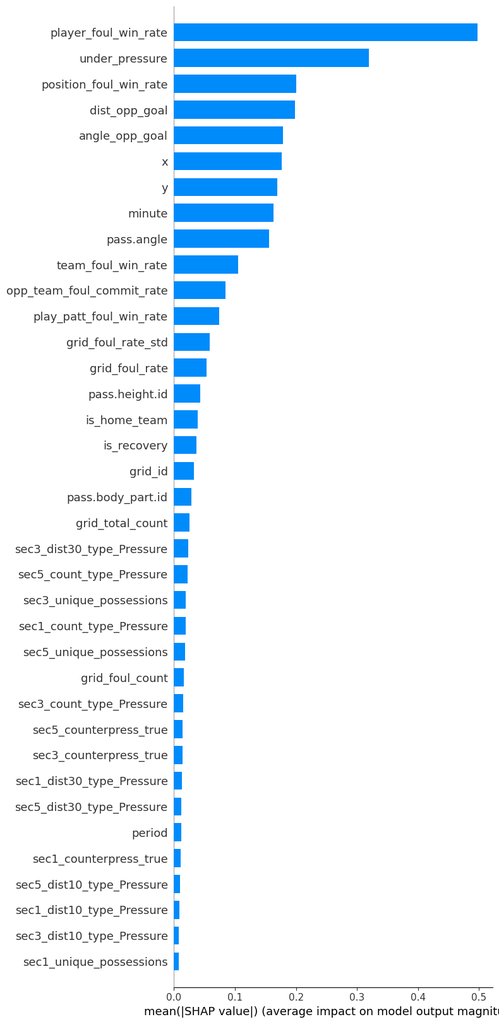

```python
# Visualize
shap.summary_plot(
    shap_values, X_train, plot_type="bar", max_display=40
)  # Bar chart of mean absolute importance
```

While we could use SHAP to do manual feature selection and retrain, since xgboost really does own feature selection process I would argue its not important to do here, so will just keep features as is

## ML Model Evaluation

How should we effectively evaluate our model?

- first, model eval on only the test (holdout) set which was data not trained on to get a best estimate of how our model would do on new data in the future

Which ML efficacy metrics?

- Since there is major class imbalance (~97.5% vs ~2.5%), **accuracy is not the right metric to look at**. You could always predict 'no foul won' (0) and get 97.5% accuracy!
- **Checking Calibration**
  - check how well calibrated our model predictions are in terms of reflecting real-world foul probabilities.
    - E.g., “When our model says there’s a 10% chance of a foul, it actually happens 10% of the time.”
- **Log Loss (a.k.a. Cross Entropy Loss)**
  - Measures how well-calibrated your predicted probabilities are.
  - Penalizes confident wrong predictions more than uncertain ones.
  - Lower is better.
- **Brier Score**
  - Measures mean squared error between predicted probabilities and actual outcomes.
  - Lower is better, more interpretable than log loss.
  - Why it's useful:
    - Can be explained as: “On average, our model’s confidence was X% off the truth.”
- **AUC-ROC (Area Under ROC Curve)**
  - Measures ability to rank positive cases higher than negative ones.
  - Insensitive to class imbalance, unlike accuracy
  - Why it helps:
    - tells how well model can separate 'foul' vs 'no foul' cases even when one is rare
- **Precision/Recall @ Threshold**
  - can select a threshold to classify 'likely foul won' or not and measure:
    - Precision = % of prediction possessions resulting in fouls won that actually were fouls won - (TP / (TP + FP)
    - Recall = % of actuals possessions resulting in fouls won model identified correctly - (TP / (TP + FN)

**Note** - In the following 'Final Results Interpretion and Analysis' section we will tie the model efficacy to likely uses and projected outcomes, especially related to betting use cases.

### Calibration Plots and understanding

calibration is to adjust raw model outputs so they better reflect real-world foul probabilities.

E.g., “When our model says there’s a 5% chance of a foul, it actually happens 5% of the time.”

Why calibration is important:

- If your model says “15% chance of a foul,” that needs to be realistic:
  - A betting company may use this to:
    - Set or adjust odds (e.g., dynamic pricing)
    - Place bets algorithmically based on perceived value vs. bookmaker line
    - Avoid overexposing risk on miscalibrated high/low outcomes
- A well-ranked model (high AUC) but poorly calibrated can:
  - Still get the order of foul likelihoods right, but
  - Overstate/understate true risk, leading to bad decisions when money is on the line.

```python
print(
    y_pred_proba.min(), y_pred_proba.max()
)  # look at min/max predicted probabilties from model
```

```
0.004894436395792532 0.1697985709397434
```

narrow range of prediction probabilities makes sense since calibrated

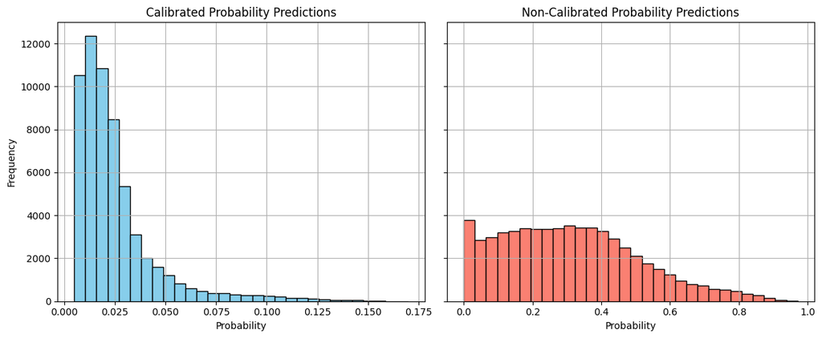

```python
fig, axes = plt.subplots(1, 2, figsize=(12, 5), sharey=True)

# Calibrated
pd.Series(y_pred_proba).hist(ax=axes[0], bins=30, color="skyblue", edgecolor="black")
axes[0].set_title("Calibrated Probability Predictions")
axes[0].set_xlabel("Probability")
axes[0].set_ylabel("Frequency")

# Non-Calibrated
base_xgb_pred_proba = base_model.predict_proba(X_test)[
    :, 1
]  # run non-calibrated xgb to generated predictions
pd.Series(base_xgb_pred_proba).hist(
    ax=axes[1], bins=30, color="salmon", edgecolor="black"
)
axes[1].set_title("Non-Calibrated Probability Predictions")
axes[1].set_xlabel("Probability")

plt.tight_layout()
plt.show()
```

We can see the difference between calibrated vs non-calibrated predictions. Calibrated a lot smaller range since giving for a given event the predicted probability of the 'foul win rate' which is generally a rare event relative of context overall.

```python
# Calibration curve
prob_true, prob_pred = calibration_curve(
    y_test, y_pred_proba, n_bins=10, strategy="quantile"
)
```

```python
# Build the table
calib_table = pd.DataFrame(
    {
        "Bin": [f"Bin {i+1}" for i in range(len(prob_pred))],
        "Avg Predicted Probability (prob_pred)": np.round(prob_pred, 5),
        "Actual Foul Rate (prob_true)": np.round(prob_true, 5),
    }
)
calib_table
```

|  | Bin | Avg Predicted Probability (prob_pred) | Actual Foul Rate (prob_true) |
| --- | --- | --- | --- |
| 0 | Bin 1 | 0.00669 | 0.00482 |
| 1 | Bin 2 | 0.00973 | 0.00947 |
| 2 | Bin 3 | 0.01246 | 0.01213 |
| 3 | Bin 4 | 0.01508 | 0.01430 |
| 4 | Bin 5 | 0.01783 | 0.01596 |
| 5 | Bin 6 | 0.02102 | 0.01912 |
| 6 | Bin 7 | 0.02468 | 0.02178 |
| 7 | Bin 8 | 0.02965 | 0.02809 |
| 8 | Bin 9 | 0.03959 | 0.04006 |
| 9 | Bin 10 | 0.07557 | 0.07545 |

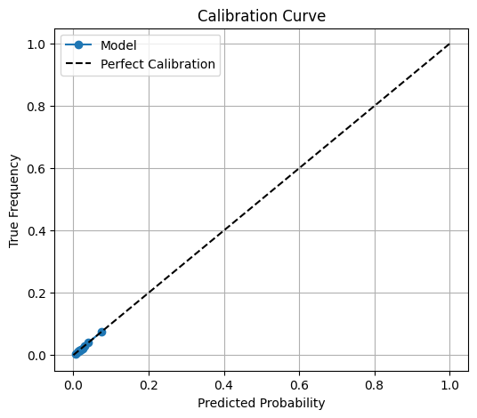

```python
# Plot calibration curve
plt.figure(figsize=(6, 5))
plt.plot(prob_pred, prob_true, marker="o", label="Model")
plt.plot([0, 1], [0, 1], "k--", label="Perfect Calibration")
plt.xlabel("Predicted Probability")
plt.ylabel("True Frequency")
plt.title("Calibration Curve")
plt.legend()
plt.grid()
plt.show()
```

From plot we see while the predicted probabilities in a small range, they are still well calibrated, which is important since the model objective is to predict the **probability** that a player will win a foul on his possession after he receives or recovers the ball. Makes sense small range since foul win rate is generally rare event

### Baseline (foul win rate) to compare against

Why we want a baseline model? Our model outputs probabilities, we want know how much better our probability predictions are compared to baseline model

Lets calculate the exact foul win rate from our training dataset first

```python
pd.Series(y_train).value_counts(normalize=True)
```

```
False    0.974511
True     0.025489
Name: proportion, dtype: float64
```

```python
p_foul_rate = pd.Series(y_train).value_counts(normalize=True)[True]
print(p_foul_rate)  # ~2.5%
```

```
0.025489243090778428
```

```python
y_baseline_pred = np.full_like(y_test, 0.03, dtype=float)
print(y_baseline_pred.shape)
```

```
(60162,)
```

```python
pd.Series(y_test).value_counts()
```

```
False    58711
True      1451
Name: count, dtype: int64
```

```python
log_loss_baseline = log_loss(y_test, y_baseline_pred)
brier_baseline = brier_score_loss(y_test, y_baseline_pred)
# since model predicts same constant prob for every sample, we know no ranking, so random guessing
auc_baseline = 0.5

print("Baseline (foul win rate) Log Loss:", log_loss_baseline)
print("Baseline (foul win rate) Brier Score:", brier_baseline)
```

```
Baseline (foul win rate) Log Loss: 0.11429650011046871
Baseline (foul win rate) Brier Score: 0.02357112130580765
```

### Xgboost model compare vs baseline

```python
# from our xgboost model
log_loss_score = log_loss(y_test, y_pred_proba)
brier_score = brier_score_loss(y_test, y_pred_proba)
roc_auc = roc_auc_score(y_test, y_pred_proba)
```

```python
metrics_df = pd.DataFrame(columns=["Model", "Log Loss", "Brier Score", "AUC-ROC"])
metrics_df.loc[len(metrics_df)] = [
    "baseline_foul_win_rate",
    log_loss_baseline,
    brier_baseline,
    auc_baseline,
]
metrics_df.loc[len(metrics_df)] = ["xgb_model", log_loss_score, brier_score, roc_auc]
metrics_df
```

|  | Model | Log Loss | Brier Score | AUC-ROC |
| --- | --- | --- | --- | --- |
| 0 | baseline_foul_win_rate | 0.114297 | 0.023571 | 0.500000 |
| 1 | xgb_model | 0.106650 | 0.023106 | 0.707539 |

reminder that lower log_loss and brier_score is better, and higher auc-roc is better.

## Final Results Interpretation and Analysis

How can we tie our technical ML metrics above to explain to non-technical users and tie more directly to business KPIs and understanding? This is the goal of this section.

Reminder from our model framing section, what are model really provides here and what exactly it is trying to predict:

**Input:** Valid possession start event - An event where a player gains possession (successful 'Ball Receipt*' or 'Ball Recovery')

**Output:** Probability that **the possession sequence** of a player results in the player winning a foul ('Foul Won')

```python
print(
    "# of test set samples (valid player possession start): {}".format(
        len(y_pred_proba)
    )
)
```

```
# of test set samples (valid player possession start): 60162
```

```python
# Calculated before (historical foul win rate from training dataset
base_frate = p_foul_rate
print("Base Rate (Foul Win Rate): {} %".format(round(base_frate * 100, 2)))
```

```
Base Rate (Foul Win Rate): 2.55 %
```

```python
def threshold_model_predict_metrics(y_test, y_pred_proba, threshold, base_rate=None):
    """
    Prints metrics for predictions above a probability threshold:
    - Number of plays selected
    - % of all plays selected
    - Actual foul rate among selected plays
    - Optional lift over base foul rate

    Parameters:
    - y_test: np.array of true labels (0/1)
    - y_pred_proba: np.array of predicted probabilities
    - threshold: float, probability cutoff (e.g., 0.025)
    - base_rate: optional float, base foul rate for lift comparison
    """
    high_conf_mask = y_pred_proba >= threshold
    selected_count = np.sum(high_conf_mask)
    total_count = len(y_test)
    selected_pct = 100 * selected_count / total_count if total_count > 0 else 0

    precision_above = np.mean(y_test[high_conf_mask]) if selected_count > 0 else 0
    lift = precision_above / base_rate if base_rate and base_rate > 0 else None

    print(f"Threshold: {round(threshold * 100, 2)}% (prob ≥ {round(threshold, 5)})")
    print(
        f"Plays predicted above threshold: {selected_count} "
        f"({round(selected_pct, 2)}% of all plays)"
    )
    print(f"Foul rate among those plays: {round(precision_above * 100, 2)}%")
    if lift:
        print(f"Lift over base rate ({round(base_rate * 100, 2)}%): {round(lift, 2)}×")
```

```python
# Assume you have y_test, y_pred_proba, and base_frate = 0.0252
threshold_model_predict_metrics(
    y_test, y_pred_proba, threshold=base_frate, base_rate=base_frate
)
```

```
Threshold: 2.55% (prob ≥ 0.02549)
Plays predicted above threshold: 19827 (32.96% of all plays)
Foul rate among those plays: 4.6%
Lift over base rate (2.55%): 1.81×
```

**result interpretation**

When the model predicted that a ‘foul won’ was **more likely than the base historical rate (≥2.55%)**, the actual foul win rate in that group was **4.6%** — which is **1.81×** higher than the baseline.

This suggests the model is successfully identifying a **meaningful subset of possession starts** where fouls are much more likely to occur.

Put another way: across all possession starts where the model flagged a **higher-than-average foul risk**, the foul actually occurred **~81% more often** than usual. This indicates the model is not just outputting numbers — it’s picking up real patterns that precede fouls and assigning probabilities that reflect that risk.

### Threshold Performance Summary

Lets calculate across some useful and relevant metrics across different thresholds

```python
def threshold_performance_summary(
    y_test, y_pred_proba, base_rate=None, percentiles=None
):
    """
    Generate a table showing actual foul rate, lift, threshold probability,
    sample counts, and coverage at different top-K percentile cutoffs.

    Parameters:
    - y_test: np.array or pd.Series of true binary labels (0 or 1)
    - y_pred_proba: np.array of predicted probabilities
    - base_rate: (optional) base foul rate. If None, computed from y_test.
    - percentiles: list of percentiles (e.g., [95, 90] = top 5%, 10%)

    Returns:
    - pd.DataFrame with performance metrics per percentile threshold
    """
    if base_rate is None:
        base_rate = np.mean(y_test)

    if percentiles is None:
        percentiles = [99, 95, 90, 85, 80, 75, 70, 65, 60, 55, 50]

    total_count = len(y_test)
    results = []

    for p in percentiles:
        thresh = np.percentile(y_pred_proba, p)
        mask = y_pred_proba >= thresh
        selected = np.sum(mask)

        if selected > 0:
            actual_rate = np.mean(y_test[mask])
            lift = actual_rate / base_rate
        else:
            actual_rate, lift = 0.0, 0.0

        results.append(
            {
                "Top K Group": f"Top {100 - p}%",
                "Threshold (Prob ≥)": round(thresh, 5),
                "# of Samples (Poss. Start events) in Group": selected,
                "% of Samples (Poss. Start events Selected": round(
                    100 * selected / total_count, 2
                ),
                "Actual Foul Rate (%)": round(100 * actual_rate, 2),
                "Lift over Base": round(lift, 2),
            }
        )

    return pd.DataFrame(results)
```

```python
res_table = threshold_performance_summary(y_test, y_pred_proba, base_rate=base_frate)
res_table
```

|  | Top K Group | Threshold (Prob ≥) | # of Samples (Poss. Start events) in Group | % of Samples (Poss. Start events Selected | Actual Foul Rate (%) | Lift over Base |
| --- | --- | --- | --- | --- | --- | --- |
| 0 | Top 1% | 0.11257 | 602 | 1.0 | 12.13 | 4.76 |
| 1 | Top 5% | 0.06769 | 3009 | 5.0 | 9.04 | 3.55 |
| 2 | Top 10% | 0.04845 | 6017 | 10.0 | 7.55 | 2.96 |
| 3 | Top 15% | 0.03896 | 9025 | 15.0 | 6.54 | 2.56 |
| 4 | Top 20% | 0.03313 | 12033 | 20.0 | 5.78 | 2.27 |
| 5 | Top 25% | 0.02951 | 15041 | 25.0 | 5.27 | 2.07 |
| 6 | Top 30% | 0.02679 | 18049 | 30.0 | 4.79 | 1.88 |
| 7 | Top 35% | 0.02465 | 21057 | 35.0 | 4.46 | 1.75 |
| 8 | Top 40% | 0.02272 | 24065 | 40.0 | 4.13 | 1.62 |
| 9 | Top 45% | 0.02100 | 27073 | 45.0 | 3.93 | 1.54 |
| 10 | Top 50% | 0.01935 | 30081 | 50.0 | 3.69 | 1.45 |

We can interpret this type of table in the same way we did for the previous section, but now have different thresholds to look at. Lets interpet a single row here

### Top 5% Group – Results Interpretation

Out of the **60,162 valid possession start events** in the test set, we focus on the **top 5% of model predictions** — the samples with the highest predicted probability of a foul being won.

The **threshold** corresponding to this top 5% is **0.06769**, meaning any possession with a model-predicted foul probability ≥ **6.77%** falls into this high-probability group.

That amounts to **3,009 samples** — exactly **5%** of the total.

Among these, the actual foul win rate was **9.04%**, which is:

- **3.55× higher** than the base rate of **2.55%**, and
- **255% more often** than average

**So What? – Potential Impact**

This shows that the model is **effective at identifying possession starts where fouls are more likely to occur.**

In practical terms: by focusing on just the top 5% of predictions, we can **more than triple our hit rate** for foul events.

**In a betting or analysis context**, this kind of concentrated lift could power:

- Selective betting strategies (e.g., live foul markets)
- Price advantage when market odds under-reflect foul likelihood

We can repeat this type of insight for other thresholds (e.g., top 10%, top 15%) using the same table — allowing us to balance **coverage** and **confidence** depending on the use case.

### Threshold Performance Summary Plots

Visualize different evaluation metrics at different thresholds, useful for understanding how useful and applicable our model is at different thresholds

```python
def plot_threshold_summary_metrics(table, y_test, base_rate_pct):
    """
    Plot Lift, Foul Rate, Sample Coverage, and Cumulative Recall from the lift table.

    Parameters:
    - table: DataFrame output from precision_lift_percentile_table
    - y_test: Original true labels (0/1) for recall calculation
    - base_rate_pct: Baseline foul rate (e.g., 0.0255)
    """
    top_k = table["Top K Group"]
    foul_rate = table["Actual Foul Rate (%)"]
    lift = table["Lift over Base"]
    sample_pct = table["% of Samples (Poss. Start events Selected"]
    sample_counts = table["# of Samples (Poss. Start events) in Group"]

    # Compute total fouls in each group
    thresholds = table["Threshold (Prob ≥)"]
    recall_counts = [np.sum((y_test >= 0) & (y_pred_proba >= t)) for t in thresholds]
    fouls_per_group = [np.sum(y_test[y_pred_proba >= t]) for t in thresholds]
    total_fouls = np.sum(y_test)
    recall_pct = [round(100 * f / total_fouls, 2) for f in fouls_per_group]

    fig, axes = plt.subplots(2, 2, figsize=(14, 10))

    # Plot 1: Lift
    axes[0, 0].bar(top_k, lift, color="skyblue")
    axes[0, 0].set_title("Lift over Base Rate")
    axes[0, 0].set_ylabel("Lift (×)")
    axes[0, 0].set_xticks(range(len(top_k)))
    axes[0, 0].set_xticklabels(top_k, rotation=45)

    # Plot 2: Actual Foul Rate
    axes[0, 1].bar(top_k, foul_rate, color="salmon")
    axes[0, 1].axhline(
        base_rate_pct * 100, color="gray", linestyle="--", label="Base Rate"
    )
    axes[0, 1].set_title("Actual Foul Rate by Top-K Group")
    axes[0, 1].set_ylabel("Foul Rate (%)")
    axes[0, 1].legend()
    axes[0, 1].set_xticks(range(len(top_k)))
    axes[0, 1].set_xticklabels(top_k, rotation=45)

    # Plot 3: Sample Coverage
    axes[1, 0].bar(top_k, sample_pct, color="lightgreen")
    axes[1, 0].set_title("Coverage (% of Possession Starts)")
    axes[1, 0].set_ylabel("% of Samples")
    axes[1, 0].set_xticks(range(len(top_k)))
    axes[1, 0].set_xticklabels(top_k, rotation=45)

    # Plot 4: Cumulative Recall (% of all fouls)
    axes[1, 1].bar(top_k, recall_pct, color="mediumpurple")
    axes[1, 1].set_title("Cumulative Recall (% of Fouls Captured)")
    axes[1, 1].set_ylabel("Recall (%)")
    axes[1, 1].set_xticks(range(len(top_k)))
    axes[1, 1].set_xticklabels(top_k, rotation=45)

    plt.tight_layout()
    plt.show()
```

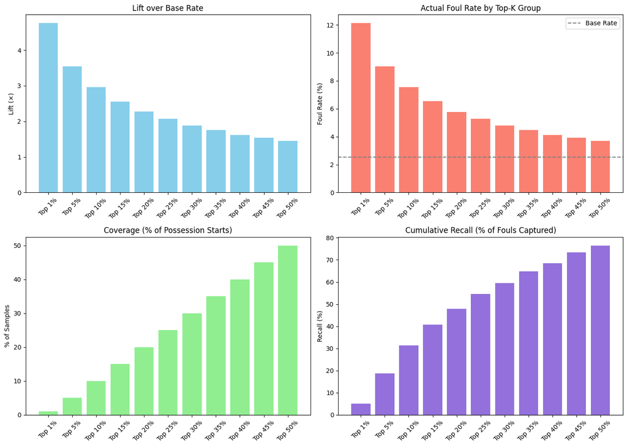

```python
plot_threshold_summary_metrics(res_table, y_test=y_test, base_rate_pct=base_frate)
```

These plots show how well the model performs as we focus on the **top X% of predicted possession starts** — those the model believes are most likely to result in a foul being won.

**Lift Over Base Rate (Top Left)**

- The **lift** shows how much more likely a foul is in each top group compared to average (baseline = 2.55%).
- For example, in the **Top 1%**, fouls are over **4.5× more likely** than average.

**Actual Foul Rate (Top Right)**

- This shows the **true foul rate** in each group.
- This shows that as the model assigns a higher foul probability to a possession start, the **real-world foul rate increases too**.
- It steadily decreases as we include lower-confidence predictions, but always stays above the base rate.

**Sample Coverage (Bottom Left)**

- This shows **how many possession starts fall into each group**.
- The higher the group (e.g., Top 50%), the more plays included — but the foul rate gets closer to average.

**Cumulative Recall (Bottom Right)**

**Key Takeaways:**

### Simulate Betting Strategy

Lets simulate some betting scenarios where we use our model predictions to determine which possession start events to bet on

```python
def simulate_betting(y_test, y_pred_proba, threshold=0.05, odds=15.0, bet_amount=1.0):
    """
    Simulate a betting strategy where a bet is placed if predicted prob ≥ threshold.

    Parameters:
    - y_test: np.array of true labels (0/1)
    - y_pred_proba: np.array of predicted probabilities
    - threshold: float, prediction cutoff for placing a bet
    - odds: float, decimal odds (means: for every $1 bet, you get $15 total payout if you win which includes your $1 stake + $14 profit)
    - bet_amount: float, amount wagered per bet

    Returns:
    - Dictionary of results
    """
    mask = y_pred_proba >= threshold
    selected = np.sum(mask)

    if selected == 0:
        return {"error": "No bets placed at this threshold."}

    y_selected = y_test[mask]
    num_wins = np.sum(y_selected)
    num_losses = selected - num_wins

    total_bet = selected * bet_amount
    total_return = num_wins * odds * bet_amount
    net_profit = total_return - total_bet
    roi = net_profit / total_bet if total_bet > 0 else 0

    return {
        "Threshold (≥)": round(threshold, 5),
        "# Bets Placed": selected,
        "# Wins": int(num_wins),
        "# Losses": int(num_losses),
        "Win Rate": round(100 * num_wins / selected, 2),
        "Total Bet ($)": round(total_bet, 2),
        "Total Return ($)": round(total_return, 2),
        "Net Profit ($)": round(net_profit, 2),
        "ROI (%)": round(100 * roi, 2),
    }
```

We know that the historical base foul win rate is 2.55%, where if you didn't know any other context, its the most basic assumption of probability of a foul won estimate.

We know that generally for betting odds, the sportsbooks won't offer odds that good.

For the sake of this simulation, we’ll assume decimal odds of 15.0, which means a \$15 total payout on a \$1 bet (i.e., \$14 profit + your \$1 stake back).

```python
# lets do 5% probability threshold and see results
simulate_betting(y_test, y_pred_proba, threshold=0.05, odds=15.0)
```

```
{'Threshold (≥)': 0.05,
 '# Bets Placed': np.int64(5625),
 '# Wins': 436,
 '# Losses': 5189,
 'Win Rate': np.float64(7.75),
 'Total Bet ($)': np.float64(5625.0),
 'Total Return ($)': np.float64(6540.0),
 'Net Profit ($)': np.float64(915.0),
 'ROI (%)': np.float64(16.27)}
```

Some net profit and ROI here

Lets simulate some differents thresholds used to make bets and odds

```python
def run_betting_simulations(
    y_test, y_pred_proba, thresholds, odds_list, bet_amount=1.0
):
    results = []

    for odds in odds_list:
        for threshold in thresholds:
            sim = simulate_betting(y_test, y_pred_proba, threshold, odds, bet_amount)
            if "error" not in sim:
                sim["Odds"] = odds
                results.append(sim)

    return pd.DataFrame(results)
```

```python
def plot_betting_roi(results_df):
    plt.figure(figsize=(10, 6))

    for odds in sorted(results_df["Odds"].unique()):
        subset = results_df[results_df["Odds"] == odds]
        plt.plot(
            subset["Threshold (≥)"], subset["ROI (%)"], marker="o", label=f"Odds {odds}"
        )

    plt.axhline(0, color="gray", linestyle="--")
    plt.title("ROI vs. Threshold for Different Odds")
    plt.xlabel("Prediction Threshold")
    plt.ylabel("ROI (%)")
    plt.legend(title="Decimal Odds")
    plt.grid(True)
    plt.tight_layout()
    plt.show()
```

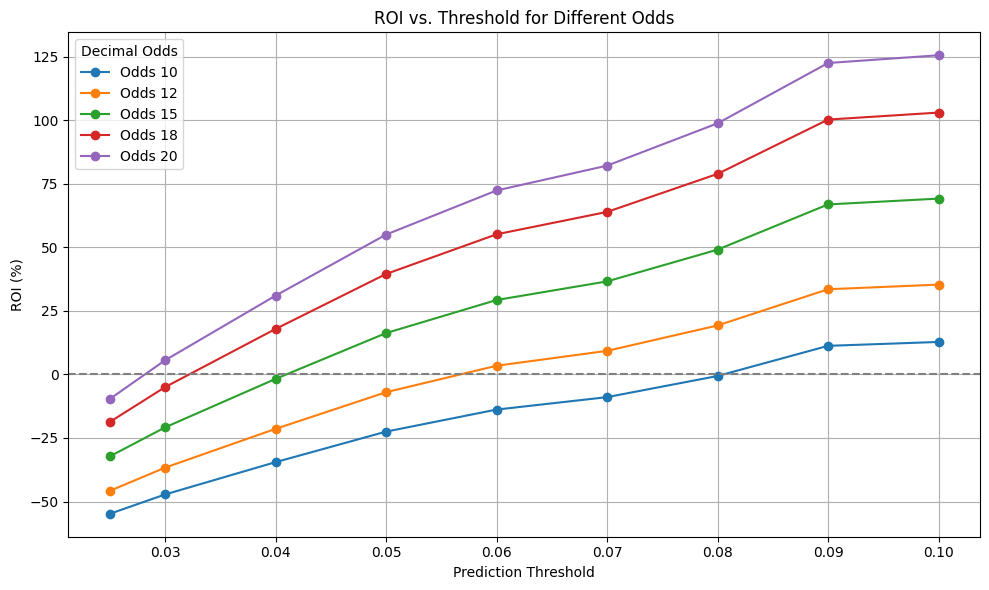

```python
thresholds = [0.025, 0.03, 0.04, 0.05, 0.06, 0.07, 0.08, 0.09, 0.10]
odds_list = [10, 12, 15, 18, 20]

betting_results = run_betting_simulations(y_test, y_pred_proba, thresholds, odds_list)
plot_betting_roi(betting_results)
```

This chart shows how profitable a betting strategy would be based on our model’s predictions.  
For each combination of **prediction threshold** (x-axis) and **decimal betting odds**, we simulate placing a $1 bet whenever the model predicts a foul probability above that threshold.

**How to read this:**

- Each line represents a different **odds level** 10 = (\$10 paid out on \$1 bet so $9 profit).
- ROI (%) shows **how much profit you'd make per dollar bet** at each threshold.
- The dashed line is the break-even point (ROI = 0%).

**Example:**

- At a **threshold of 0.05** (i.e., model predicts ≥5% foul chance), and using **odds = 15**, the strategy would yield a **~16.27% ROI**.
- In contrast, betting at lower odds like 10 results in **negative ROI** unless you're extremely selective.
- The model is useful for identifying **profitable betting opportunities** — but only when paired with **favorable odds**.
- **Higher thresholds** (e.g., 0.07–0.10) lead to better ROI because we bet less often, but with **more accurate predictions**.

## Next Steps and Improvement Ideas

- reserach and experiment with more advanced modeling and feature extraction such as Transformers or GNN embeddings on the spatial components and/or sequence modeling of actions.
- Spend more time building and trying other features
- try some other modeling architectures and approaches other than xgboost and compare.
  - potentailly ensembling multiple model predictions can lead to lift in efficacy, common approach in kaggle competitions
- can we leverage same data source from other previous seasons or even other leagues? Generally more data we can leverage the better.
- spend more time on building out more comprehensive evaluation metrics and graphs to help visualize and interpret results and how they can be used in a betting context. Maybe setup some betting simulations with hypothetical gains/losses
- more EDA and visualization tooling to understand the data and its nuances
- optimize and cleanup code

Other features that I would want to try and create and see if I can get any lift from:

- **refereree historical foul rate** - certain referees generally call more fouls than others
- **fouls in match** - how many fouls in match have already occured (can also normalize by time in game)
- **opposing player on_card proximity** - any players close in proximity right before player gets possession already on card? If so less likely to foul I would think.
- **current scoreline** - if the match is a blowout, less likely to be fouls potentially, if team is holding a lead, may foul strategically to waste time.
- **match importance** - could build a proxy feature for this that captures league positions, point in time in season.
- **advanced spatial and temporal embeddings-based features** - explore using Transformers or GNNs to automatically learn dense numerical features from the spatial and temporal aspects of the data. (need to think about this more)
- **all player locations (x,y) at snapshots in time** - this data isn't available in what is provided, but would provide a lot of value if location data on players per < 1 second snapshots available to build features on. Improve spatial and temporal context.